# **Local Insights, Better Valuation: A Practical Model for Real Estate Pricing**

**By: Tibaria Al Nouri, Shameka Burnett, & Rachel Robbins-Mayhill** IST 707, Spring 2025  
Professor Bolton, Syracuse University  
Due: 03/24/2025

# **Project Introduction**

## **Background:**

In the real estate market, accurate home pricing is crucial for buyers, sellers, and investors. However, traditional valuation methods—such as comparative market analysis (CMA) and manual appraisals—are often subjective, time-consuming, and prone to human bias. These inefficiencies can lead to overpriced or underpriced properties, resulting in lost revenue opportunities or prolonged listing durations. Thus, a machine learning model that can evaluate large amounts of data and assess without reliance on human intuition would be a novel way to establish home values.

For this project, we are working on behalf of a Real Estate company. The object our team is tasked with is designing a machine learning based home price prediction model. The benefit would be the model could analyze vast amounts of real estate data to provide accurate, data-driven valuations.The primary goal of the model and exploration is to benefit the company’s Real Estate agents who can use the model and insights to recommend competitive listing prices, reducing the time properties stay on the market. Home Sellers and Buyers will also benefit because they can reliably price their homes accurately using another data point besides an assessor, while buyers can ensure they are making fair offers.

## **Dataset Description:**

The “House Sales in King County, USA” dataset provides information on home sales in the Seattle, WA area between May 2014 and May 2015. While it lacks detailed metadata, its frequent use in educational and analytical settings suggests a reasonable level of reliability. The dataset is publicly available on Kaggle: House Sales in King County, USA. No additional datasets will be used for this project.

The dataset is large enough to train complex models but still computationally feasible, containing 21,613 observations (rows) and 21 features (columns), including the target variable, “price,” making it suitable for supervised learning. The features include:

| Feature | Definition | Data Type |
| --- | --- | --- |
| id | Identifier for the house record | Integer |
| date | Date house was sold | Object |
| Price (target) | Price house sold for in USD | Float |
| bedrooms | Quantity of bedrooms | Integer |
| bathrooms | Quantity of bathrooms | Float |
| sqft_living | Square footage of the home | Integer |
| sqft_lot | Square footage of the land | Integer |
| floors | Total levels (floors) in the home | Float |
| waterfront | Indicates home has a waterfront view; 0 = no, 1 = yes | Integer |
| view | An index from 0 to 4 of how good the view of the property was. 0 represents no good view, 4 represents very good view. | Integer |
| condition | An index from 1 to 5 on the condition of the house. 1 represents poorer condition, and 5 represents superb condition. | Integer |
| grade | An index from 1 to 13. 1 to 3 falls short of building construction and design, 7 has an average level of construction and design, and 11 to 13 have higher quality level of construction and design. | Integer |
| sqft_above | Square feet of the home above ground level | Integer |
| sqft_basement | Square feet of the home below ground level | Integer |
| yr_built | Year the home was built | Integer |
| yr_renovated | Year the home was last renovated | Integer |
| zipcode | Zipcode of the home | Integer |
| lat | Latitude of the home | Float |
| long | Longitude of the home | Float |
| sqft_living15 | The average square footage of interior housing living space for the nearest 15 neighboring houses | Integer |
| sqft_lot15 | The average square footage of land space for the nearest 15 neighboring houses | Integer |

# **Data Acquisition**

## **A. Load Libraries**

To facilitate data exploration, preprocessing, modeling, and evaluation, the necessary Python libraries are imported and categorized based on their purpose:

These libraries ensure a comprehensive workflow from **data exploration to preprocessing, modeling, evaluation, and deployment**.

## **B. Load the Data**

There are two ways to load the data:

1. **Directly from Kaggle** using the `kagglehub` library.
2. **Uploading the dataset manually** as a CSV file.

### **Option 1: Load Data from Kaggle**

The `kagglehub` package is used to fetch the latest version of the dataset from Kaggle. This approach eliminates the need for manual downloads.

1. **Install dependencies if needed**: Ensure `kagglehub` is installed.
2. **Set the dataset path**: The dataset `"harlfoxem/housesalesprediction"` contains a file named `"kc_house_data.csv"`.
3. **Load the data**: The dataset is retrieved in a Pandas DataFrame.
4. **Initial Inspection**: The `.info()` method is used to check data types, missing values, and dataset structure.

### **Option 2: Upload CSV Manually**

Alternatively, users can upload the `"kc_house_data.csv"` file to their working directory and read it into a Pandas DataFrame using:

```
import pandas as pd
df = pd.read_csv("kc_house_data.csv")
df.info()
```

### **Load Libraries**

```python
# ==============================================
# Core Libraries for Data Handling & Visualization
# ==============================================

import numpy as np  # Numerical computations
import pandas as pd  # Data manipulation and analysis
import matplotlib.pyplot as plt  # General plotting
import seaborn as sns  # Statistical visualizations
sns.set()  # Apply seaborn's default styling

# Install necessary package (only needed once in a new environment)
!pip install contextily

import contextily as ctx  # Basemaps for geospatial visualizations
import geopandas as gpd  # Geospatial data handling
import matplotlib.ticker as ticker  # Adjusting tick marks on plots
import matplotlib.ticker as mtick  # Formatting percentages and large numbers
import matplotlib.colors as mcolors  # Color normalization and scaling for heatmaps
from IPython.display import display  # Display multiple outputs in Jupyter cells

# ==============================================
# Data Preprocessing & Feature Engineering
# ==============================================

from sklearn.pipeline import Pipeline  # Constructing sequential transformations
from sklearn.compose import ColumnTransformer  # Applying different transformations per column type
from sklearn.impute import SimpleImputer, KNNImputer  # Handling missing values
from sklearn.preprocessing import (
    StandardScaler,  # Standardization (zero mean, unit variance)
    MinMaxScaler,  # Scaling features to a fixed range (0 to 1)
    OrdinalEncoder,  # Encoding ordinal categorical variables
    OneHotEncoder,  # Encoding nominal categorical variables
    LabelEncoder,  # Encoding target variables if needed
    FunctionTransformer,  # Custom feature transformations
)

from scipy.stats import (
    zscore,  # Outlier detection
    boxcox,  # Box-Cox transformation for skewed data
    skew,  # Skewness calculation
    chi2_contingency,  # Categorical feature importance
)

# Handling multicollinearity
from statsmodels.stats.outliers_influence import variance_inflation_factor

# ==============================================
# Data Splitting & Model Evaluation
# ==============================================

from sklearn.model_selection import (
    train_test_split,  # Splitting dataset into training and test sets
    cross_val_score,  # Cross-validation
    KFold,  # K-fold cross-validation strategy
    GridSearchCV,  # Hyperparameter tuning
)

from sklearn.metrics import (
    mean_squared_error,  # RMSE Calculation
    r2_score,  # R² Score for model performance
)

from sklearn.base import BaseEstimator, TransformerMixin  # Custom transformers

# ==============================================
# Regression & Predictive Models
# ==============================================

from sklearn.linear_model import LinearRegression  # Linear regression
from sklearn.ensemble import (
    RandomForestRegressor,  # Random Forest Regression
    GradientBoostingRegressor,  # Gradient Boosting Regression
)

# ==============================================
# Clustering & Geospatial Analysis
# ==============================================

from sklearn.cluster import KMeans  # K-Means Clustering
from sklearn.cluster import DBSCAN  # Density-Based Spatial Clustering (DBSCAN)

# ==============================================
# Dimensionality Reduction & Feature Selection
# ==============================================

from sklearn.decomposition import PCA  # Principal Component Analysis (PCA)

# ==============================================
# Explainability & Model Interpretation
# ==============================================

import shap  # SHAP values for feature importance

# ==============================================
# Randomization & Model Persistence
# ==============================================

import random  # Setting random seed
import joblib  # Saving and loading trained models

# ==============================================
# Final Setup & Configuration
# ==============================================

# Set random seed for reproducibility
SEED = 42
np.random.seed(SEED)
random.seed(SEED)
```

```python
# OPTION 1 Read data from Kaggle

# Install dependencies as needed:
# pip install kagglehub[pandas-datasets]
import kagglehub
from kagglehub import KaggleDatasetAdapter

# Set the path to the file you'd like to load: The dataset "harlfoxem/housesalesprediction" contains a file named "kc_house_data.csv".
file_path = "kc_house_data.csv"

# Load the latest version
df = kagglehub.dataset_load(
  KaggleDatasetAdapter.PANDAS,
  "harlfoxem/housesalesprediction",
  file_path, #any additional args
  # documenation for more information:
  # https://github.com/Kaggle/kagglehub/blob/main/README.md#kaggledatasetadapterpandas
)

df.info()
```

```
<class 'pandas.core.frame.DataFrame'>
RangeIndex: 21613 entries, 0 to 21612
Data columns (total 21 columns):
 #   Column         Non-Null Count  Dtype
---  ------         --------------  -----
 0   id             21613 non-null  int64
 1   date           21613 non-null  object
 2   price          21613 non-null  float64
 3   bedrooms       21613 non-null  int64
 4   bathrooms      21613 non-null  float64
 5   sqft_living    21613 non-null  int64
 6   sqft_lot       21613 non-null  int64
 7   floors         21613 non-null  float64
 8   waterfront     21613 non-null  int64
 9   view           21613 non-null  int64
 10  condition      21613 non-null  int64
 11  grade          21613 non-null  int64
 12  sqft_above     21613 non-null  int64
 13  sqft_basement  21613 non-null  int64
 14  yr_built       21613 non-null  int64
 15  yr_renovated   21613 non-null  int64
 16  zipcode        21613 non-null  int64
 17  lat            21613 non-null  float64
 18  long           21613 non-null  float64
 19  sqft_living15  21613 non-null  int64
 20  sqft_lot15     21613 non-null  int64
dtypes: float64(5), int64(15), object(1)
memory usage: 3.5+ MB
```

```python
# OPTION 2 Read data from uploading the csv to this google collab session
#file_path = '/content/kc_house_data.csv'
#df = pd.read_csv(file_path)
#df.head()
```

```python
# Drop duplicates and create a new DataFrame
exploring_df = df.drop_duplicates()

# Display the info of DataFrame after dropping duplicates
print("DataFrame Ready for Exploration (After Dropping Duplicates):")
exploring_df.info()
print("\n")

# View the first 5 rows transposed
exploring_df.head(5).T
```

```
DataFrame Ready for Exploration (After Dropping Duplicates):
<class 'pandas.core.frame.DataFrame'>
RangeIndex: 21613 entries, 0 to 21612
Data columns (total 21 columns):
 #   Column         Non-Null Count  Dtype
---  ------         --------------  -----
 0   id             21613 non-null  int64
 1   date           21613 non-null  object
 2   price          21613 non-null  float64
 3   bedrooms       21613 non-null  int64
 4   bathrooms      21613 non-null  float64
 5   sqft_living    21613 non-null  int64
 6   sqft_lot       21613 non-null  int64
 7   floors         21613 non-null  float64
 8   waterfront     21613 non-null  int64
 9   view           21613 non-null  int64
 10  condition      21613 non-null  int64
 11  grade          21613 non-null  int64
 12  sqft_above     21613 non-null  int64
 13  sqft_basement  21613 non-null  int64
 14  yr_built       21613 non-null  int64
 15  yr_renovated   21613 non-null  int64
 16  zipcode        21613 non-null  int64
 17  lat            21613 non-null  float64
 18  long           21613 non-null  float64
 19  sqft_living15  21613 non-null  int64
 20  sqft_lot15     21613 non-null  int64
dtypes: float64(5), int64(15), object(1)
memory usage: 3.5+ MB
```

|  | 0 | 1 | 2 | 3 | 4 |
| --- | --- | --- | --- | --- | --- |
| id | 7129300520 | 6414100192 | 5631500400 | 2487200875 | 1954400510 |
| date | 20141013T000000 | 20141209T000000 | 20150225T000000 | 20141209T000000 | 20150218T000000 |
| price | 221,900.00 | 538,000.00 | 180,000.00 | 604,000.00 | 510,000.00 |
| bedrooms | 3 | 3 | 2 | 4 | 3 |
| bathrooms | 1.00 | 2.25 | 1.00 | 3.00 | 2.00 |
| sqft_living | 1180 | 2570 | 770 | 1960 | 1680 |
| sqft_lot | 5650 | 7242 | 10000 | 5000 | 8080 |
| floors | 1.00 | 2.00 | 1.00 | 1.00 | 1.00 |
| waterfront | 0 | 0 | 0 | 0 | 0 |
| view | 0 | 0 | 0 | 0 | 0 |
| condition | 3 | 3 | 3 | 5 | 3 |
| grade | 7 | 7 | 6 | 7 | 8 |
| sqft_above | 1180 | 2170 | 770 | 1050 | 1680 |
| sqft_basement | 0 | 400 | 0 | 910 | 0 |
| yr_built | 1955 | 1951 | 1933 | 1965 | 1987 |
| yr_renovated | 0 | 1991 | 0 | 0 | 0 |
| zipcode | 98178 | 98125 | 98028 | 98136 | 98074 |
| lat | 47.51 | 47.72 | 47.74 | 47.52 | 47.62 |
| long | -122.26 | -122.32 | -122.23 | -122.39 | -122.05 |
| sqft_living15 | 1340 | 1690 | 2720 | 1360 | 1800 |
| sqft_lot15 | 5650 | 7639 | 8062 | 5000 | 7503 |

**Insights from Initial Data Acquisition**

**Removal of Duplicate Entries**

- No duplicate records were identified, as evidenced by the overall dataset remaining at **21,613** observations following the command to drop duplicates.

# **Exploratory Data Analysis**

This section explores the dataset to understand feature distributions, relationships, and potential preprocessing needs before modeling. The primary goal is to identify patterns that influence home pricing and inform feature engineering and preprocessing strategies.

The insights gained from this exploratory analysis guide the preprocessing and feature engineering steps, ensuring the modeling phase is built on a well-structured and meaningful dataset.

### **Explore the Data: Descriptive Statistics Computation for Numeric Feature Evaluation**

```python
# Disable scientific notation globally for all outputs
pd.options.display.float_format = "{:,.2f}".format  # Ensures numbers use standard notation with commas

def analyze_descriptive_statistics(df, skew_threshold=1.0, outlier_iqr_factor=1.5, placeholder_threshold=0.05):
    """
    Identifies potential data issues using descriptive statistics:
    - Skewed features (suggesting transformation)
    - Outliers (suggesting further review)
    - Scaling needs (features with high variance)
    - Placeholder values (e.g., dominant values like 999)

    Parameters:
    - df: DataFrame to analyze
    - skew_threshold: Skewness above this value suggests transformation (default = 1.0).
    - outlier_iqr_factor: IQR multiplier to identify outliers (default = 1.5).
    - placeholder_threshold: Proportion of dataset a value must appear in to be considered a placeholder (default = 5%)

    Returns:
    - DataFrame summarizing key findings for preprocessing.
    """

    # Exclude datetime columns from analysis
    num_df = df.select_dtypes(include=["number"]).copy()

    # Compute descriptive statistics
    stats = num_df.describe().T
    stats["skew"] = num_df.skew()

    # Calculate IQR for outlier detection
    stats["IQR"] = stats["75%"] - stats["25%"]
    stats["lower_bound"] = stats["25%"] - (outlier_iqr_factor * stats["IQR"])
    stats["upper_bound"] = stats["75%"] + (outlier_iqr_factor * stats["IQR"])

    # Count potential outliers
    stats["outlier_count"] = stats.index.map(
        lambda col: num_df[(num_df[col] < stats.loc[col, "lower_bound"]) | (num_df[col] > stats.loc[col, "upper_bound"])].shape[0]
    )
    stats["outlier_count"] = stats["outlier_count"].astype(int)  # Convert to integer

    # Identify recommended actions
    stats["recommended_action"] = "No action needed"
    stats.loc[stats["skew"].abs() > skew_threshold, "recommended_action"] = "Check skewness; consider log or power transformation"
    stats.loc[stats["outlier_count"] > 0, "recommended_action"] = "Check outliers; consider winsorizing or capping"
    stats.loc[stats["std"] > 10 * stats["50%"], "recommended_action"] = "Consider scaling (StandardScaler or MinMaxScaler)"
    stats.loc[stats["std"] == 0, "recommended_action"] = "Drop feature (constant value)"

    # Detect potential placeholder values dynamically
    for col in num_df.columns:
        common_values = num_df[col].value_counts(normalize=True)
        placeholders = common_values[common_values > placeholder_threshold].index.tolist()
        if len(placeholders) == 1:
            stats.loc[col, "recommended_action"] = f"Check placeholder value ({placeholders[0]})"

    # **Final Formatting for Readability**
    stats = stats.round(2)  # Round values to 2 decimal places

    # Display results in Jupyter Lab
    display(stats[["count", "mean", "std", "min", "25%", "50%", "75%", "max", "skew", "outlier_count", "recommended_action"]])

    return stats
```

```python
# Run the analysis
preprocessing_recommendations = analyze_descriptive_statistics(exploring_df)
```

|  | count | mean | std | min | 25% | 50% | 75% | max | skew | outlier_count | recommended_action |
| --- | --- | --- | --- | --- | --- | --- | --- | --- | --- | --- | --- |
| id | 21,613.00 | 4,580,301,520.86 | 2,876,565,571.31 | 1,000,102.00 | 2,123,049,194.00 | 3,904,930,410.00 | 7,308,900,445.00 | 9,900,000,190.00 | 0.24 | 0 | No action needed |
| price | 21,613.00 | 540,088.14 | 367,127.20 | 75,000.00 | 321,950.00 | 450,000.00 | 645,000.00 | 7,700,000.00 | 4.02 | 1146 | Check outliers; consider winsorizing or capping |
| bedrooms | 21,613.00 | 3.37 | 0.93 | 0.00 | 3.00 | 3.00 | 4.00 | 33.00 | 1.97 | 546 | Check outliers; consider winsorizing or capping |
| bathrooms | 21,613.00 | 2.11 | 0.77 | 0.00 | 1.75 | 2.25 | 2.50 | 8.00 | 0.51 | 571 | Check outliers; consider winsorizing or capping |
| sqft_living | 21,613.00 | 2,079.90 | 918.44 | 290.00 | 1,427.00 | 1,910.00 | 2,550.00 | 13,540.00 | 1.47 | 572 | Check outliers; consider winsorizing or capping |
| sqft_lot | 21,613.00 | 15,106.97 | 41,420.51 | 520.00 | 5,040.00 | 7,618.00 | 10,688.00 | 1,651,359.00 | 13.06 | 2425 | Check outliers; consider winsorizing or capping |
| floors | 21,613.00 | 1.49 | 0.54 | 1.00 | 1.00 | 1.50 | 2.00 | 3.50 | 0.62 | 0 | No action needed |
| waterfront | 21,613.00 | 0.01 | 0.09 | 0.00 | 0.00 | 0.00 | 0.00 | 1.00 | 11.39 | 163 | Check placeholder value (0) |
| view | 21,613.00 | 0.23 | 0.77 | 0.00 | 0.00 | 0.00 | 0.00 | 4.00 | 3.40 | 2124 | Check placeholder value (0) |
| condition | 21,613.00 | 3.41 | 0.65 | 1.00 | 3.00 | 3.00 | 4.00 | 5.00 | 1.03 | 30 | Check outliers; consider winsorizing or capping |
| grade | 21,613.00 | 7.66 | 1.18 | 1.00 | 7.00 | 7.00 | 8.00 | 13.00 | 0.77 | 1911 | Check outliers; consider winsorizing or capping |
| sqft_above | 21,613.00 | 1,788.39 | 828.09 | 290.00 | 1,190.00 | 1,560.00 | 2,210.00 | 9,410.00 | 1.45 | 611 | Check outliers; consider winsorizing or capping |
| sqft_basement | 21,613.00 | 291.51 | 442.58 | 0.00 | 0.00 | 0.00 | 560.00 | 4,820.00 | 1.58 | 496 | Check placeholder value (0) |
| yr_built | 21,613.00 | 1,971.01 | 29.37 | 1,900.00 | 1,951.00 | 1,975.00 | 1,997.00 | 2,015.00 | -0.47 | 0 | No action needed |
| yr_renovated | 21,613.00 | 84.40 | 401.68 | 0.00 | 0.00 | 0.00 | 0.00 | 2,015.00 | 4.55 | 914 | Check placeholder value (0) |
| zipcode | 21,613.00 | 98,077.94 | 53.51 | 98,001.00 | 98,033.00 | 98,065.00 | 98,118.00 | 98,199.00 | 0.41 | 0 | No action needed |
| lat | 21,613.00 | 47.56 | 0.14 | 47.16 | 47.47 | 47.57 | 47.68 | 47.78 | -0.49 | 2 | Check outliers; consider winsorizing or capping |
| long | 21,613.00 | -122.21 | 0.14 | -122.52 | -122.33 | -122.23 | -122.12 | -121.32 | 0.89 | 256 | Consider scaling (StandardScaler or MinMaxScaler) |
| sqft_living15 | 21,613.00 | 1,986.55 | 685.39 | 399.00 | 1,490.00 | 1,840.00 | 2,360.00 | 6,210.00 | 1.11 | 544 | Check outliers; consider winsorizing or capping |
| sqft_lot15 | 21,613.00 | 12,768.46 | 27,304.18 | 651.00 | 5,100.00 | 7,620.00 | 10,083.00 | 871,200.00 | 9.51 | 2194 | Check outliers; consider winsorizing or capping |

```python
# Count unique values for categorical features
print(exploring_df.nunique())

# Check for Missing Values
print("\nMissing Values:\n", exploring_df.isnull().sum())
```

```
id               21436
date               372
price             4028
bedrooms            13
bathrooms           30
sqft_living       1038
sqft_lot          9782
floors               6
waterfront           2
view                 5
condition            5
grade               12
sqft_above         946
sqft_basement      306
yr_built           116
yr_renovated        70
zipcode             70
lat               5034
long               752
sqft_living15      777
sqft_lot15        8689
dtype: int64

Missing Values:
 id               0
date             0
price            0
bedrooms         0
bathrooms        0
sqft_living      0
sqft_lot         0
floors           0
waterfront       0
view             0
condition        0
grade            0
sqft_above       0
sqft_basement    0
yr_built         0
yr_renovated     0
zipcode          0
lat              0
long             0
sqft_living15    0
sqft_lot15       0
dtype: int64
```

**Observations:Preprocessing Actions Based on Descriptive Statistics**

**Transformations for Skewed Distributions**

- **Apply log transformation** to highly skewed features: `price` (4.02 skew, 1,146 outliers), `sqft_lot` (13.06 skew, 2,425 outliers), `sqft_living15`, and `sqft_lot15`.
- **Review outliers** in `sqft_living` and `sqft_basement` for potential capping or winsorizing.

**Feature Engineering**

- **Extract time-based features** from `date`, such as **year, month, and seasonality indicators**.
- **Convert `yr_renovated` to a binary feature** (`0 = not renovated, 1 = renovated`) due to high skew (4.55) and 914 outliers.

**Encoding Categorical Variables**

**Data Type Adjustments**

- **Convert `floors` from float to integer** since it represents discrete levels.

**Scaling & Outlier Handling**

- **Scale `lat` and `long`** (StandardScaler or MinMaxScaler) due to high cardinality and 256 outliers in longitude.
- **Apply appropriate scaling** to numerical features with high variance to improve model stability.

**Missing Value Considerations**

These adjustments will be applied in the preprocessing phase of the pipeline to help optimize feature distributions and ensure the model generalizes well.

### **Explore the Data: Examine Price & Feature Distributions**

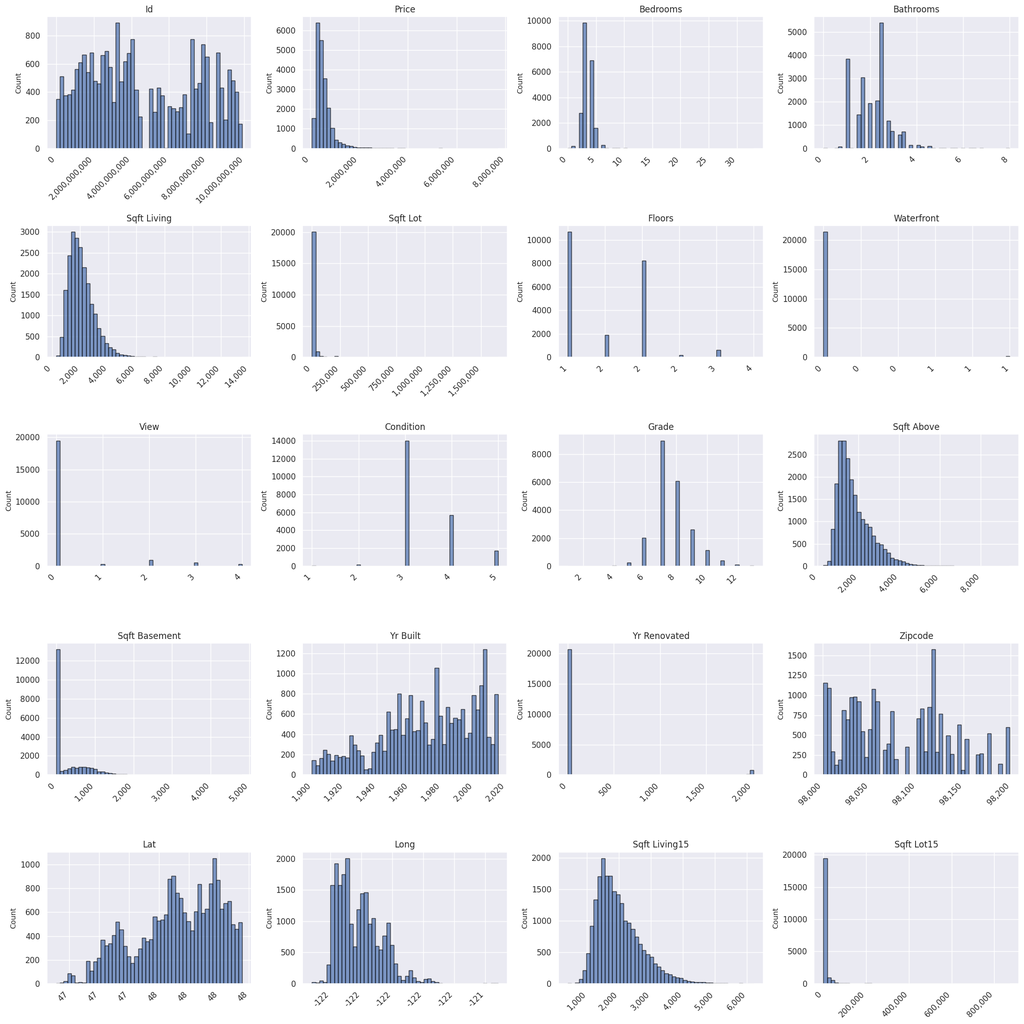

```python
# Select only numeric columns
numeric_features = exploring_df.select_dtypes(include=['number']).columns

# Define grid size dynamically
n_cols = 4  # Number of columns in the grid
n_rows = int(np.ceil(len(numeric_features) / n_cols))  # Calculate required rows

# Create the figure and axes
fig, axes = plt.subplots(n_rows, n_cols, figsize=(20, n_rows * 4))  # Adjust grid size
axes = axes.flatten()  # Flatten axes for easy iteration

# Iterate through numeric features and plot histograms
for i, col in enumerate(numeric_features):
    ax = axes[i]
    exploring_df[col].hist(bins=50, ax=ax, edgecolor="black", alpha=0.7)

    # Title & formatting
    ax.set_title(col.replace("_", " ").title(), fontsize=12)
    ax.set_xlabel("")
    ax.set_ylabel("Count", fontsize=10)

    # Remove scientific notation & format large numbers with commas
    ax.ticklabel_format(style='plain', axis='x')
    ax.xaxis.set_major_formatter(mtick.FuncFormatter(lambda x, _: f"{x:,.0f}"))

    # Rotate x-axis labels for better readability
    plt.setp(ax.xaxis.get_majorticklabels(), rotation=45, ha="right")

# Hide any empty subplots if they exist
for j in range(i + 1, len(axes)):
    fig.delaxes(axes[j])

# Optimize layout spacing
plt.tight_layout()
plt.show()
```

**Observations:**

- **Price distribution** is highly skewed, with a concentration of homes priced under $1,000,000 but a long tail of expensive properties. A **log transformation** will be applied to stabilize variance and improve model performance.
- **Bedrooms and bathrooms** exhibit clustering at common values (e.g., 3-4 bedrooms, 2-3 bathrooms), reinforcing their relevance in home valuation. Extreme values (e.g., 10+ bedrooms) will be reviewed for potential outlier treatment.
- **Sqft living and sqft lot** show extreme right skewness, particularly **sqft_lot**, where a few properties have massive land areas. **Log transformation or winsorization** will be considered to mitigate this effect.
- **Floors, view, condition, and grade** have limited unique values, making them more categorical in nature. **Encoding or binning strategies** will be evaluated for modeling.
- **Waterfront property** is highly imbalanced, with very few homes classified as waterfront. Its predictive power will be assessed, and adjustments may be made if needed.
- **Year built and year renovated** show meaningful distributions, with spikes around major housing booms. **Year renovated** will be converted into a binary indicator to capture its impact.
- **Zip codes** have a diverse spread, meaning **location-based features like price per zip code or clustering by region** will be explored.
- **Latitude and longitude** indicate a clear geographical spread of home prices. **Scaling will be applied**, and spatial clustering will be used to analyze market segments.

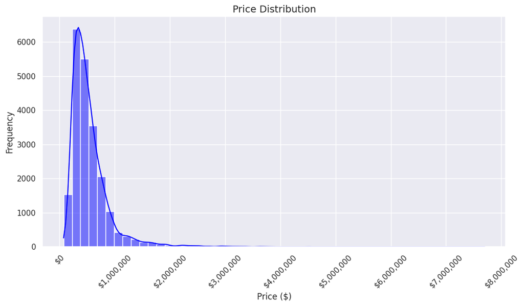

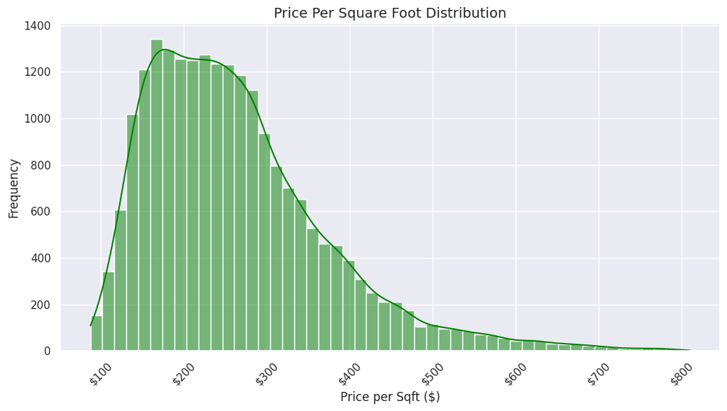

```python
# Price Distribution (Histogram)
plt.figure(figsize=(12, 6))
sns.histplot(exploring_df["price"], bins=50, kde=True, color="blue")
plt.title("Price Distribution", fontsize=14)
plt.xlabel("Price ($)", fontsize=12)
plt.ylabel("Frequency", fontsize=12)

# Formatting: Remove scientific notation & add commas/dollar signs
plt.ticklabel_format(style='plain', axis='x')
plt.gca().xaxis.set_major_formatter(mtick.FuncFormatter(lambda x, _: f"${x:,.0f}"))
plt.xticks(rotation=45)

plt.show()


# Price per Square Foot
exploring_df["price_per_sqft"] = exploring_df["price"] / exploring_df["sqft_living"]

plt.figure(figsize=(12, 6))
sns.histplot(exploring_df["price_per_sqft"], bins=50, kde=True, color="green")
plt.title("Price Per Square Foot Distribution", fontsize=14)
plt.xlabel("Price per Sqft ($)", fontsize=12)
plt.ylabel("Frequency", fontsize=12)

# Formatting
plt.ticklabel_format(style='plain', axis='x')
plt.gca().xaxis.set_major_formatter(mtick.FuncFormatter(lambda x, _: f"${x:,.0f}"))
plt.xticks(rotation=45)

plt.show()
```

**Observations:**

- The price distribution is highly skewed, with a large concentration of properties in the lower price range and fewer properties at the higher end. This suggests that most homes in the dataset are within a more affordable range, while luxury properties make up a small percentage of the market.
- A log transformation of price may be beneficial for modeling to normalize the distribution and improve predictive performance.
- The price per square foot distribution is more symmetric but still slightly skewed, indicating that while home sizes and prices vary, there is a general range where most properties fall.
- The peak in price per square foot around $200-$300 suggests a common pricing standard in the area, which could be a useful benchmark for valuation.
- The long tail in both distributions implies that luxury properties significantly impact the overall market, meaning segmenting properties by price tier or location may improve valuation accuracy.
- For business applications, this reinforces the importance of pricing strategies—standard-priced homes will have more competition, while high-end homes may require different marketing and pricing tactics.

### **Explore the Data: Relationships Between Price and Features**

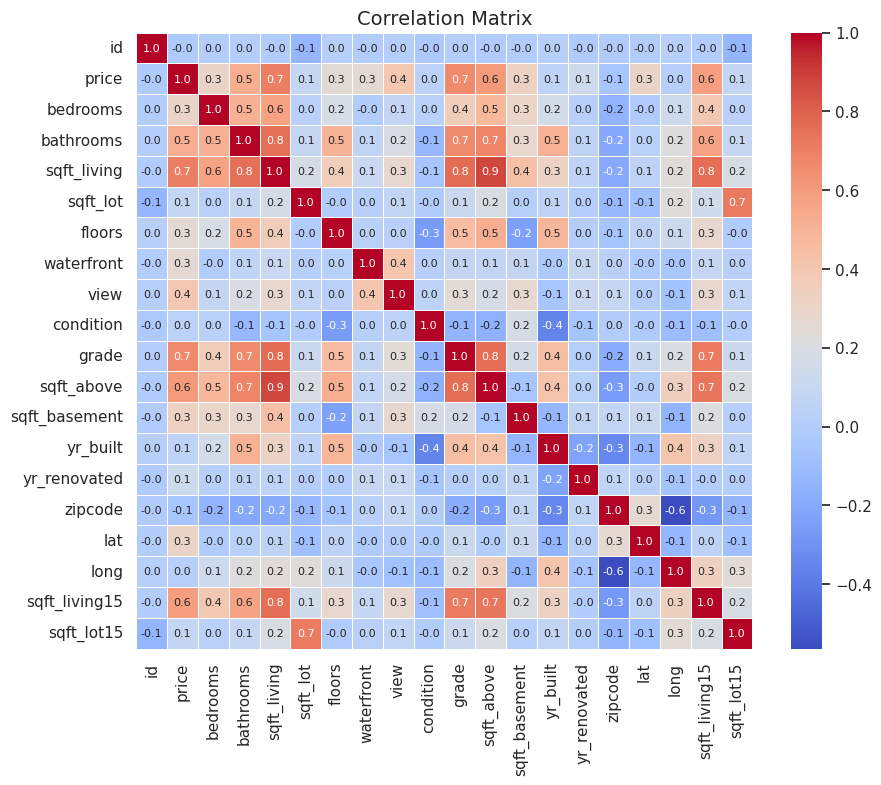

```python
num_features = df.select_dtypes(include=np.number)

corr_matrix = num_features.corr()

# Create a larger figure
plt.figure(figsize=(10, 8))

# Plot the heatmap with seaborn
sns.heatmap(
    corr_matrix,
    annot=True,          # Display the correlation values
    fmt=".1f",           # Format the correlation values
    cmap="coolwarm",     # Use the same color map
    cbar=True,           # Add a colorbar
    square=True,         # Make cells square
    linewidths=0.5,       # Add a subtle grid line
    annot_kws= {"size": 8}
)

# Add a title
plt.title("Correlation Matrix", fontsize=14)

# Display the plot
plt.show()
```

**Observations:**

### **Explore the Data: Geospatial Analysis of Housing Prices**

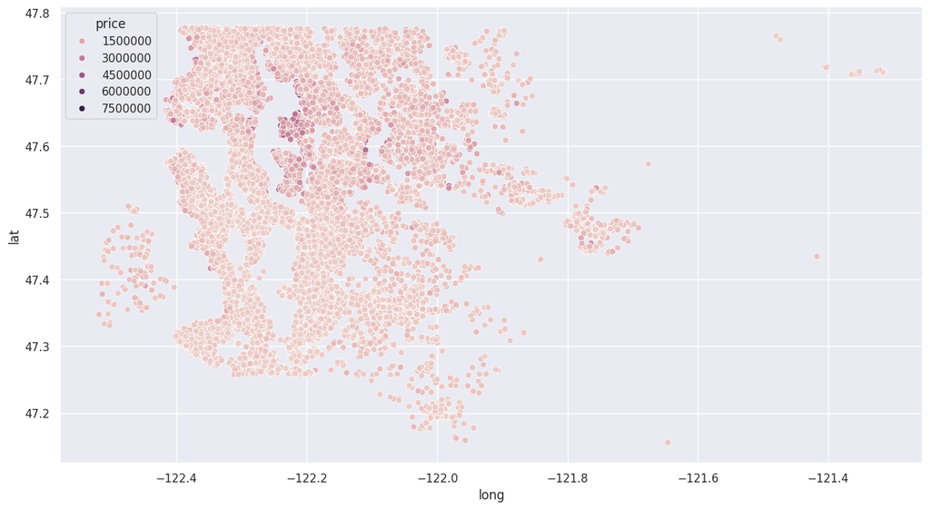

```python
plt.figure(figsize = (15, 8))
sns.scatterplot(x = 'long', y = 'lat', hue = 'price', data = exploring_df)
```

**Observations:**

Many of the houses along Seattle's Puget Sound (far left edge) and particularly homes on the east side of Lake Washington (the grey mass in the center) are priced higher than most other homes. These cities include Bellevue, Kirkland, and Redmond which are tech hubs.

[figure not shown]

```python
fig, ax = plt.subplots(figsize=(12, 8))

# Create hexbin plot
scatter = ax.hexbin(df["long"], df["lat"], C=df["price"], gridsize=100, cmap="YlOrRd", reduce_C_function=np.mean)

# Add OpenStreetMap background
ctx.add_basemap(ax, crs="EPSG:4326", source=ctx.providers.OpenStreetMap.Mapnik)

# Improve colorbar labeling
cbar = plt.colorbar(scatter)
cbar.set_label("Price ($M)")
cbar.ax.yaxis.set_major_formatter(ticker.FuncFormatter(lambda x, _: f"${x/1e6:.1f}M"))

# Annotate major cities
city_labels = {
    (-122.33, 47.61): "Seattle",
    (-122.20, 47.62): "Bellevue",
    (-122.44, 47.25): "Tacoma"
}
for (long, lat), city in city_labels.items():
    ax.text(long, lat, city, fontsize=10, fontweight="bold", color="black", ha="center")

# Labels and title
plt.xlabel("Longitude")
plt.ylabel("Latitude")
plt.title("King County Home Prices (Hexbin Density Map)")
plt.show()
```

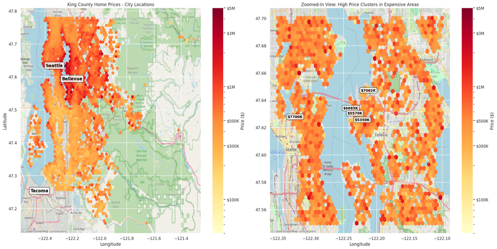

```python
# Find top high-price locations
high_price_areas = exploring_df.groupby(["lat", "long"])["price"].mean().nlargest(5).reset_index()

# Define zoom-in boundaries (adjusted for the most expensive neighborhoods)
zoom_min_lat, zoom_max_lat = 47.55, 47.70
zoom_min_long, zoom_max_long = -122.35, -122.10

# Set up figure with two subplots
fig, axes = plt.subplots(1, 2, figsize=(20, 10), sharex=False, sharey=False)

# Apply log normalization for better price visibility
norm = mcolors.LogNorm(vmin=50000, vmax=5000000)

### --- LEFT PLOT: Full King County City Map ---
ax1 = axes[0]
scatter1 = ax1.hexbin(
    exploring_df["long"], exploring_df["lat"],
    C=exploring_df["price"],
    gridsize=75, cmap="YlOrRd",
    norm=norm,
    reduce_C_function=np.mean
)
ctx.add_basemap(ax1, crs="EPSG:4326", source=ctx.providers.OpenStreetMap.Mapnik)

ax1.set_xlabel("Longitude")
ax1.set_ylabel("Latitude")
ax1.set_title("King County Home Prices - City Locations")

# Annotate major city names
city_labels = {
    (-122.33, 47.61): ("Seattle", 0.02),
    (-122.20, 47.61): ("Bellevue", -0.02),
    (-122.44, 47.25): ("Tacoma", 0)
}

for (long, lat), (city, y_offset) in city_labels.items():
    ax1.text(
        long, lat + y_offset, city, fontsize=12, fontweight="bold", color="black", ha="center",
        bbox=dict(facecolor="white", alpha=0.8, edgecolor="black", boxstyle="round,pad=0.3")
    )

cbar1 = plt.colorbar(scatter1, ax=ax1, label="Price ($)")
cbar1.ax.set_yticks([100000, 300000, 500000, 1000000, 3000000, 5000000])
cbar1.ax.set_yticklabels(["$100K", "$300K", "$500K", "$1M", "$3M", "$5M"])

### --- RIGHT PLOT: Zoomed-In High-Priced Clusters ---
ax2 = axes[1]
scatter2 = ax2.hexbin(
    exploring_df[(exploring_df["lat"].between(zoom_min_lat, zoom_max_lat)) &
                 (exploring_df["long"].between(zoom_min_long, zoom_max_long))]["long"],
    exploring_df[(exploring_df["lat"].between(zoom_min_lat, zoom_max_lat)) &
                 (exploring_df["long"].between(zoom_min_long, zoom_max_long))]["lat"],
    C=exploring_df["price"],
    gridsize=50, cmap="YlOrRd",
    norm=norm,
    reduce_C_function=np.mean
)
ctx.add_basemap(ax2, crs="EPSG:4326", source=ctx.providers.OpenStreetMap.Mapnik)

ax2.set_xlabel("Longitude")
ax2.set_title("Zoomed-In View: High Price Clusters in Expensive Areas")

# Add high-price annotations with slight offsets
np.random.seed(42)
jitter_x = np.random.uniform(-0.002, 0.002, len(high_price_areas))
jitter_y = np.random.uniform(-0.004, 0.004, len(high_price_areas))

for i, (_, row) in enumerate(high_price_areas.iterrows()):
    if zoom_min_lat <= row["lat"] <= zoom_max_lat and zoom_min_long <= row["long"] <= zoom_max_long:
        ax2.text(
            row["long"] + jitter_x[i], row["lat"] + jitter_y[i], f"${int(row['price']/1000)}K",
            fontsize=10, fontweight="bold", color="black", ha="center",
            bbox=dict(facecolor="white", alpha=0.8, edgecolor="black", boxstyle="round,pad=0.3")
        )

cbar2 = plt.colorbar(scatter2, ax=ax2, label="Price ($)")
cbar2.ax.set_yticks([100000, 300000, 500000, 1000000, 3000000, 5000000])
cbar2.ax.set_yticklabels(["$100K", "$300K", "$500K", "$1M", "$3M", "$5M"])

plt.tight_layout()
plt.show()
```

**Observations:**

**Exploratory Perspective:**

- A clear spatial pattern exists, with higher home prices concentrated around Seattle and Bellevue.
- A zoomed-in analysis of the most expensive areas highlights distinct high-price clusters.
- Geographic dispersion suggests that pricing varies significantly across the county, with coastal areas and regions closer to urban centers commanding higher values.

**Business Problem Insight:**

- The spatial concentration of high-priced homes indicates a premium on urban accessibility and waterfront locations, which could help agents prioritize key valuation factors.
- Home sellers in premium areas may benefit from pricing strategies that reflect competitive clusters rather than broad county-wide trends.
- Buyers can use these insights to determine where they are likely to face more competitive bidding and price inflation.

**Modeling Perspective:**

- Latitude and longitude should be retained as features, with potential interactions or transformations to better capture regional pricing effects.
- Location-based clustering methods, such as K-Means, may improve model segmentation by grouping properties with similar pricing behaviors.
- Spatial outliers (isolated high-priced properties) might need additional review to determine if they represent unique valuation cases (e.g., luxury estates) or data inconsistencies.

### **Explore the Data: Price Distribution by Zip Code**

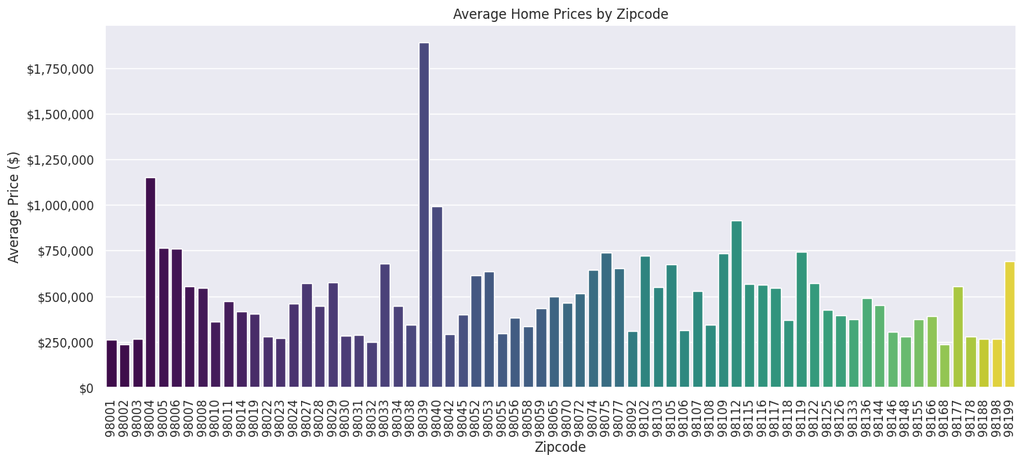

```python
# Compute Median Price by ZIP Code
zipcode_price = exploring_df.groupby("zipcode")["price"].median().reset_index()

# Create the figure
plt.figure(figsize=(15, 6))

# Bar plot with explicit hue and palette
sns.barplot(
    x=zipcode_price["zipcode"],
    y=zipcode_price["price"],
    hue=zipcode_price["zipcode"],
    palette="viridis",
    legend=False  # Disable legend for readability
)

# Rotate x-axis labels for better readability
plt.xticks(rotation=90)
plt.xlabel("Zipcode")
plt.ylabel("Average Price ($)")

# Format y-axis to **disable scientific notation**
plt.gca().yaxis.set_major_formatter(mtick.FuncFormatter(lambda x, _: f"${x:,.0f}"))

# Add title
plt.title("Average Home Prices by Zipcode")

# Show plot
plt.show()
```

**Observations:**

**Exploratory Perspective:**

**Business Problem Insight:**

- High-priced zip codes likely correspond to high-demand neighborhoods or exclusive areas, which can guide real estate agents in identifying premium markets.
- Understanding zip code price variations helps in setting competitive listing prices and identifying emerging market trends.
- Buyers and sellers can use this insight to gauge property affordability and expected investment returns based on location.

**Modeling Perspective:**

- Zip code should be treated as a categorical feature, likely requiring one-hot encoding or target encoding to capture its impact on pricing.
- Additional location-based attributes such as neighborhood amenities, school ratings, or transportation access could enhance predictive power.
- Extreme price variations in certain zip codes may require further investigation to determine whether outliers exist or if price segmentation is necessary.

### **Explore the Data: Clustering (Unsupervised Learning) for Market Segmentation - Based on Home Features**

```python
# Select Features for Clustering (excluding lat/long to focus on property traits)
features_for_clustering = exploring_df[[
    "price_per_sqft", "sqft_living", "sqft_basement",
    "bedrooms", "bathrooms", "grade", "condition",
    "view", "waterfront", "sqft_lot"
]]

# Standardize features for better clustering performance
scaler = StandardScaler()
scaled_features = scaler.fit_transform(features_for_clustering)

# Apply K-Means Clustering
kmeans = KMeans(n_clusters=5, random_state=42)
exploring_df["kmeans_cluster"] = kmeans.fit_predict(scaled_features)
```

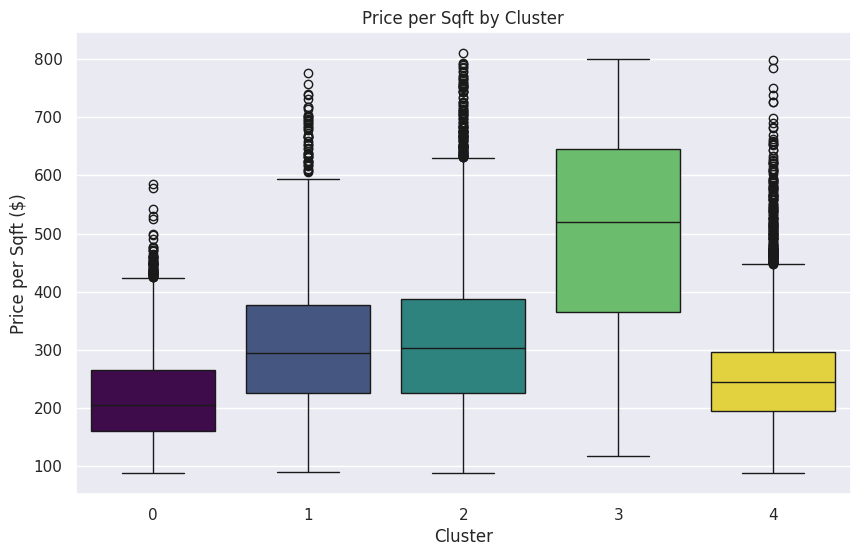

```python
# Visualize Clusters (Market Segments)
plt.figure(figsize=(10, 6))
sns.boxplot(
    x="kmeans_cluster",
    y="price_per_sqft",
    data=exploring_df,
    hue="kmeans_cluster",
    palette="viridis",
    legend=False
)
plt.title("Price per Sqft by Cluster")
plt.xlabel("Cluster")
plt.ylabel("Price per Sqft ($)")
plt.show()
```

```python
# Compute Summary Statistics per Cluster
cluster_summary = exploring_df.groupby("kmeans_cluster").agg({
    "price_per_sqft": "median",
    "price": "median",
    "sqft_living": "median",
    "sqft_basement": "median",
    "bedrooms": "median",
    "bathrooms": "median",
    "grade": "median",
    "condition": "median",
    "view": "median",
    "waterfront": "mean",  # Proportion of waterfront homes in each cluster
    "sqft_lot": "median",
}).reset_index()

# Display Summary
display(cluster_summary)
```

|  | kmeans_cluster | price_per_sqft | price | sqft_living | sqft_basement | bedrooms | bathrooms | grade | condition | view | waterfront | sqft_lot |
| --- | --- | --- | --- | --- | --- | --- | --- | --- | --- | --- | --- | --- |
| 0 | 0 | 205.22 | 405,000.00 | 1,990.00 | 0.00 | 3.00 | 2.25 | 7.00 | 3.00 | 0.00 | 0.00 | 7,500.00 |
| 1 | 1 | 293.88 | 800,000.00 | 2,850.00 | 800.00 | 4.00 | 2.50 | 9.00 | 3.00 | 2.00 | 0.00 | 9,603.00 |
| 2 | 2 | 303.91 | 367,750.00 | 1,240.00 | 0.00 | 3.00 | 1.00 | 7.00 | 3.00 | 0.00 | 0.00 | 6,750.00 |
| 3 | 3 | 519.08 | 1,400,000.00 | 2,850.00 | 500.00 | 3.00 | 2.50 | 9.00 | 3.00 | 4.00 | 1.00 | 17,342.00 |
| 4 | 4 | 244.51 | 760,000.00 | 3,120.00 | 0.00 | 4.00 | 2.75 | 9.00 | 3.00 | 0.00 | 0.00 | 9,687.00 |

```python
# Assign meaningful labels based on cluster characteristics
cluster_labels = {
    0: "Standard Mid-Sized Homes",
    1: "Large Homes with Basements",
    2: "Affordable Small Homes",
    3: "Luxury Waterfront Homes",
    4: "Large Mid-Range Homes"
}

# Map the labels
exploring_df["cluster_label"] = exploring_df["kmeans_cluster"].map(cluster_labels)

# Display to verify unique cluster assignments
print(exploring_df[["kmeans_cluster", "cluster_label"]].drop_duplicates())
```

```
    kmeans_cluster               cluster_label
0                2      Affordable Small Homes
1                0    Standard Mid-Sized Homes
5                4       Large Mid-Range Homes
15               1  Large Homes with Basements
49               3     Luxury Waterfront Homes
```

```python
exploring_df.info()
```

```
<class 'pandas.core.frame.DataFrame'>
RangeIndex: 21613 entries, 0 to 21612
Data columns (total 24 columns):
 #   Column          Non-Null Count  Dtype
---  ------          --------------  -----
 0   id              21613 non-null  int64
 1   date            21613 non-null  object
 2   price           21613 non-null  float64
 3   bedrooms        21613 non-null  int64
 4   bathrooms       21613 non-null  float64
 5   sqft_living     21613 non-null  int64
 6   sqft_lot        21613 non-null  int64
 7   floors          21613 non-null  float64
 8   waterfront      21613 non-null  int64
 9   view            21613 non-null  int64
```

[output cut: 16 more lines]

**Observations:**

**Exploratory Perspective**

**Business Problem Insights**

- **Identifying Target Markets:** The segmentation allows real estate agents to better tailor pricing strategies and marketing efforts based on home characteristics.
- **Understanding Market Dynamics:** The clustering reveals that certain homes (e.g., waterfront properties) command a premium price per square foot, while larger suburban homes may have more moderate pricing per sqft.
- **Enhancing Pricing Recommendations:** Real estate agents can use these clusters to recommend competitive listing prices that align with similar properties.
- **Luxury vs. Standard Homes:** The presence of a distinct Luxury Waterfront Homes cluster reinforces that buyers in this segment have different valuation expectations compared to standard mid-sized or affordable homes.

**Modeling Perspective**

- **Cluster Labels as Features:** Assigning homes to clusters can act as an additional categorical feature, improving model performance by incorporating market segmentation directly.
- **Price per Square Foot Variance:** The variance within clusters suggests that some homes may require further sub-segmentation or additional contextual factors.
- **Feature Selection Considerations:** The clustering results suggest strong segmentation based on square footage, grade, and waterfront status, highlighting the importance of these features in predictive modeling.
- **Handling Outliers:** The luxury clusters show significantly higher price per sqft, which may require log transformations or separate modeling approaches for different home segments.

# **Data Preprocessing**

### **Preprocessing Steps Based on Observations**

The exploratory data analysis identified key considerations for preprocessing to enhance model performance and interpretability. The following steps will be applied in sequence to prepare the data for machine learning.

**1. Data Splitting Before Processing**

- The dataset will be split into **training (80%) and test (20%) sets** before applying any transformations. This prevents data leakage by ensuring that preprocessing steps are only learned from the training set and applied separately to the test set.

**2. Handling Placeholder Values**

- Some features contain **placeholder values instead of true missing values**, such as:
  - **Year Renovated:** `0` represents "never renovated." A **binary indicator (renovated vs. not renovated)** will be created.
  - **Basement Square Footage:** `0` likely means "no basement," which will be kept but may be used to derive a categorical feature.
  - **View & Waterfront:** `0` in these features likely indicates "no view" or "not waterfront," so they will be treated as meaningful categories rather than missing values.

**3. Handling Multicollinearity**

- **Simple Feature Reduction:**
  - Highly correlated features introduce redundancy (`sqft_living`, `sqft_above`, `sqft_living15`). One will be **removed based on correlation analysis**.
  - **Bathrooms and bedrooms** may also show correlation in certain cases; feature importance analysis will guide inclusion.
- **Variance Inflation Factor (VIF) Analysis:**
  - If needed, additional features will be removed based on **VIF scores above 10**, indicating excessive collinearity.

**4. Outlier Detection and Treatment**

- **Price & Square Footage:** Extreme skewness was observed in price and price per square foot. Outliers will be treated using **Z-score analysis and IQR filtering**, especially in high-end properties.
- **Waterfront Properties:** Significant variance in pricing suggests applying a **log transformation** on price to normalize the distribution.
- **Lot Size:** Large disparities in lot size, especially at the high end, may require **capping or transformation** to reduce skew.

**6. Feature Engineering**

- **Price Efficiency Metrics:**
  - **Price per Square Foot** (already calculated) will be used to capture pricing trends more effectively.
  - **Price per Bedroom** and **Price per Bathroom** will be added for better cost-efficiency analysis.
- **Geospatial Features:**
  - Latitude and longitude will be retained and potentially **transformed using polynomial or clustering techniques**.
  - **Zip Code Aggregation:** Median price and price per square foot at the **zip code level** will be added to incorporate neighborhood effects.
- **Clustering-Based Features:**
  - The K-Means clusters (e.g., "Luxury Waterfront Homes," "Affordable Small Homes") will be included as categorical variables.
- **Time-Based Features:**
  - **Year Sold → Seasonal Adjustments:** Extracted into **month and year bins** to capture seasonal pricing trends.

**7. Encoding Categorical Variables**

- **Cluster Labels:** Ordinal encoding will be used to retain the natural ordering of property types.
- **Condition, Grade, and View:** One-hot encoding will be applied where appropriate to enhance interpretability.

**8. Feature Scaling**

- **Standardization (StandardScaler):** Applied to numerical features such as square footage, lot size, and price per square foot for model consistency.
- **Log Transformations:** Applied to skewed numerical features, particularly **price** and **lot size**, to improve normality.

**Possible Additional Steps**

- Validate preprocessing using **cross-validation** and assess performance with and without engineered features.
- **Bin high-price clusters separately** to improve predictive accuracy for luxury properties.
- **Experiment with non-linear models** (e.g., Random Forest, XGBoost) to capture complex relationships.

By addressing the patterns identified in EDA, this preprocessing pipeline ensures data integrity, better model interpretability, and enhanced predictive accuracy.

### **Split the Data**

```python
# Load dataset
process_df = exploring_df.copy()

# Ensure correct data types before splitting
if "date" in process_df.columns:
    print("Dropping 'date' column.")
    process_df.drop(columns=["date"], inplace=True)  # Drop datetime column

# Define target variable
y = process_df["price"]
X = process_df.drop(columns=["price", "id", "cluster_label"])  # Drop unique/non-predictive features

# Check for missing values before splitting
missing_values = X.isnull().sum()
if missing_values.any():
    print("Warning: Missing values detected before split. Handling may be required.")

# Split data before any transformations
X_train, X_test, y_train, y_test = train_test_split(
    X, y, test_size=0.2, random_state=42
)

# Verification
print(f"Data Split Completed: Training Set: {X_train.shape}, Test Set: {X_test.shape}")

# Verify consistency in feature columns
assert set(X_train.columns) == set(X_test.columns), "Mismatch in train/test feature columns!"
X.info()
```

```
Dropping 'date' column.
Data Split Completed: Training Set: (17290, 20), Test Set: (4323, 20)
<class 'pandas.core.frame.DataFrame'>
RangeIndex: 21613 entries, 0 to 21612
Data columns (total 20 columns):
 #   Column          Non-Null Count  Dtype
---  ------          --------------  -----
 0   bedrooms        21613 non-null  int64
 1   bathrooms       21613 non-null  float64
 2   sqft_living     21613 non-null  int64
 3   sqft_lot        21613 non-null  int64
 4   floors          21613 non-null  float64
 5   waterfront      21613 non-null  int64
 6   view            21613 non-null  int64
 7   condition       21613 non-null  int64
 8   grade           21613 non-null  int64
 9   sqft_above      21613 non-null  int64
 10  sqft_basement   21613 non-null  int64
 11  yr_built        21613 non-null  int64
 12  yr_renovated    21613 non-null  int64
 13  zipcode         21613 non-null  int64
 14  lat             21613 non-null  float64
 15  long            21613 non-null  float64
 16  sqft_living15   21613 non-null  int64
 17  sqft_lot15      21613 non-null  int64
 18  price_per_sqft  21613 non-null  float64
 19  kmeans_cluster  21613 non-null  int32
dtypes: float64(5), int32(1), int64(14)
memory usage: 3.2 MB
```

### **Handle Placeholder Values:**

```python
# Handling Placeholder Values

# Create binary indicator for renovated homes
X_train["was_renovated"] = (X_train["yr_renovated"] > 0).astype(int)
X_test["was_renovated"] = (X_test["yr_renovated"] > 0).astype(int)

# Ensure basement presence is correctly interpreted
X_train["has_basement"] = (X_train["sqft_basement"] > 0).astype(int)
X_test["has_basement"] = (X_test["sqft_basement"] > 0).astype(int)

# Convert 'view' and 'waterfront' to categorical since 0 is meaningful
X_train["view"] = X_train["view"].astype(str)
X_test["view"] = X_test["view"].astype(str)
X_train["waterfront"] = X_train["waterfront"].astype(str)
X_test["waterfront"] = X_test["waterfront"].astype(str)

# Drop original yr_renovated and sqft_basement since we created new features
X_train.drop(columns=["yr_renovated", "sqft_basement"], inplace=True)
X_test.drop(columns=["yr_renovated", "sqft_basement"], inplace=True)

# Verification
print("Placeholder values handled. New Features: 'was_renovated', 'has_basement'")
print(X_train[["was_renovated", "has_basement", "view", "waterfront"]].head())
```

```
Placeholder values handled. New Features: 'was_renovated', 'has_basement'
       was_renovated  has_basement view waterfront
6325               0             0    0          0
13473              0             1    0          0
17614              0             1    0          0
16970              0             1    0          0
20868              0             1    0          0
```

```python
# Function to check for missing values
def check_missing_values(df, name):
    missing_values = df.isnull().sum()
    missing_percent = (missing_values / len(df)) * 100
    missing_summary = pd.DataFrame({
        "Missing Values": missing_values,
        "Percentage": missing_percent
    })
    print(f"\n🔍 Null Value Assessment for {name}:\n")
    display(missing_summary[missing_summary["Missing Values"] > 0])

# Check for missing values in X_train and X_test
check_missing_values(X_train, "X_train")
check_missing_values(X_test, "X_test")
```

```
🔍 Null Value Assessment for X_train:
```

|  | Missing Values | Percentage |
| --- | --- | --- |

```
🔍 Null Value Assessment for X_test:
```

|  | Missing Values | Percentage |
| --- | --- | --- |

**Observations:**

### **Handle Multicolinearity**

```python
def reduce_sqft_multicollinearity(df, threshold=10):
    """Remove highly correlated square footage-related features while keeping the best one."""
    df = df.copy()

    # Select only size-based features for VIF analysis
    sqft_features = ["sqft_living", "sqft_above", "sqft_living15", "sqft_lot"]
    sqft_df = df[sqft_features]

    vif_data = pd.DataFrame()
    vif_data["feature"] = sqft_df.columns
    vif_data["VIF"] = [variance_inflation_factor(sqft_df.values, i) for i in range(sqft_df.shape[1])]

    # Remove features with VIF > threshold, keeping at least one representative feature
    features_to_remove = vif_data[vif_data["VIF"] > threshold]["feature"].tolist()

    # Retain the most predictive square footage feature
    keep_feature = "sqft_living"  # Assuming this is the best overall predictor

    if keep_feature in features_to_remove:
        features_to_remove.remove(keep_feature)

    # Drop selected features from the dataset
    df = df.drop(columns=features_to_remove, errors="ignore")

    print(f"Removed square footage features with high VIF (keeping {keep_feature}): {features_to_remove}")
    return df

# Apply to training data
X_train = reduce_sqft_multicollinearity(X_train, threshold=10)

# Ensure test set retains only the selected features
X_test = X_test[X_train.columns]

print("Multicollinearity Adjusted for Square Footage Features")
```

```
Removed square footage features with high VIF (keeping sqft_living): ['sqft_above', 'sqft_living15']
Multicollinearity Adjusted for Square Footage Features
```

**Observations:**

The initial approach applied VIF to all numerical features, removing those with VIF > 10. This eliminated too many features, including important predictors such as **bedrooms, bathrooms, grade, zipcode, and price_per_sqft**. While it reduced multicollinearity, it also risked over-simplifying the dataset.

Adjusting the threshold to **15** was tested to make the method less aggressive. This helped retain more features but still removed key predictors, leading to unnecessary information loss.

This strategy ensures multicollinearity is reduced while preserving interpretability and predictive power. It prevents over-simplification, maintains valuable business insights, and balances complexity with accuracy.

### **Outlier Detection & Treatment:**

```python
# Handle Outliers Using IQR Method
def detect_outliers_iqr(df, columns):
    """Cap extreme outliers using IQR method."""
    df = df.copy()
    for col in columns:
        if col in df.columns:  # Ensure column exists
            Q1 = df[col].quantile(0.25)
            Q3 = df[col].quantile(0.75)
            IQR = Q3 - Q1
            lower_bound = Q1 - 1.5 * IQR
            upper_bound = Q3 + 1.5 * IQR
            df[col] = np.clip(df[col], lower_bound, upper_bound)
    return df

# Define columns for outlier treatment
outlier_columns = ["sqft_living", "sqft_lot", "price_per_sqft", "sqft_lot15"]
```

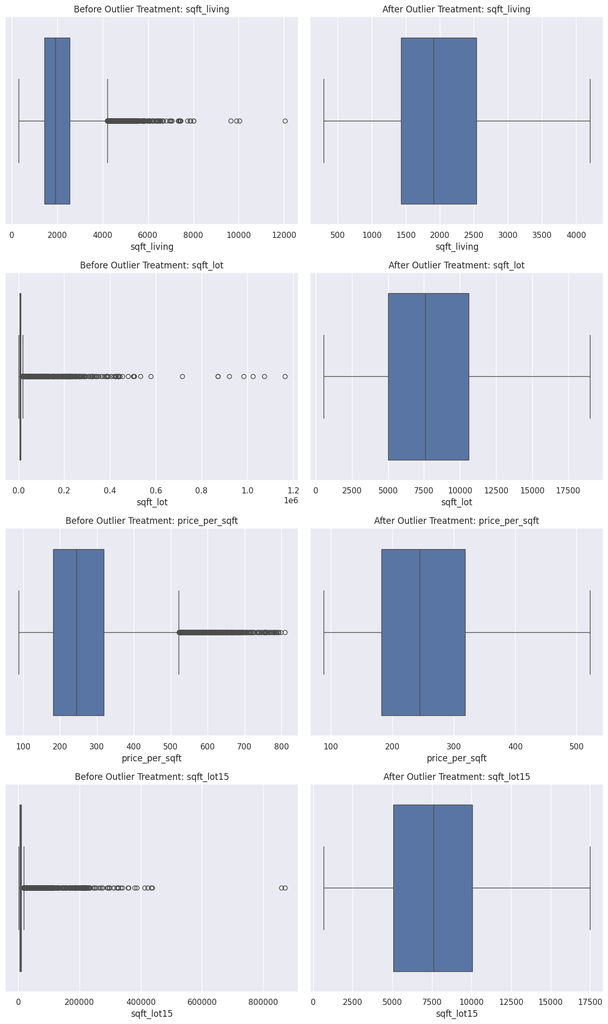

```
Outlier Treatment Applied & Verified
```

```python
# Function to visualize distributions before and after outlier treatment
def plot_outlier_treatment(df_before, df_after, columns):
    """Plot before and after distributions for outlier-treated features."""
    fig, axes = plt.subplots(nrows=len(columns), ncols=2, figsize=(12, 5 * len(columns)))

    for i, col in enumerate(columns):
        if col in df_before.columns and col in df_after.columns:
            # Before Outlier Treatment
            sns.boxplot(x=df_before[col], ax=axes[i, 0])
            axes[i, 0].set_title(f"Before Outlier Treatment: {col}")

            # After Outlier Treatment
            sns.boxplot(x=df_after[col], ax=axes[i, 1])
            axes[i, 1].set_title(f"After Outlier Treatment: {col}")

    plt.tight_layout()
    plt.show()

# Make a copy before outlier treatment for comparison
X_train_before_outlier = X_train.copy()
X_test_before_outlier = X_test.copy()

# Apply outlier detection only to existing columns
X_train = detect_outliers_iqr(X_train, outlier_columns)
X_test = detect_outliers_iqr(X_test, outlier_columns)

# Verify changes visually
plot_outlier_treatment(X_train_before_outlier, X_train, outlier_columns)

print("Outlier Treatment Applied & Verified")
```

**Observations:**

The before-treatment boxplots for sqft_living and sqft_lot show significant outliers, particularly on the higher end. Many extreme values exist, which could distort the model if left untreated.

After applying outlier treatment using IQR-based capping, the distributions appear more controlled. The highest values have been capped, reducing skewness while maintaining a reasonable range for most properties.

This approach preserves important information while ensuring extreme values do not overly influence predictions.

### **Apply Log Transformation to Skewed Data**

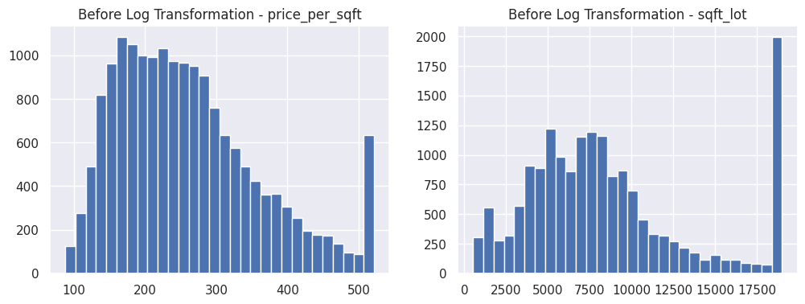

```
Log Transformations Applied to Skewed Features
```

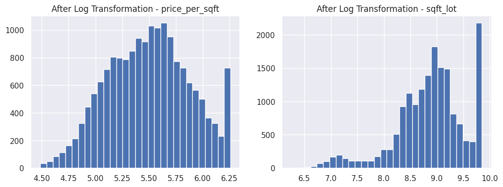

```python
# Log Transformations for Skewed Features

# Identify features to transform
log_features = [feature for feature in ["price_per_sqft", "sqft_lot", "sqft_lot_15"] if feature in X_train.columns]

# Visualize Before Transformation
fig, axes = plt.subplots(1, len(log_features), figsize=(12, 4))
for i, feature in enumerate(log_features):
    axes[i].hist(X_train[feature], bins=30)
    axes[i].set_title(f"Before Log Transformation - {feature}")

plt.show()

# Apply log transformation
for feature in log_features:
    X_train[feature] = np.log1p(X_train[feature])
    X_test[feature] = np.log1p(X_test[feature])

# Verification & Visualizing After Transformation
print("Log Transformations Applied to Skewed Features")

fig, axes = plt.subplots(1, len(log_features), figsize=(12, 4))
for i, feature in enumerate(log_features):
    axes[i].hist(X_train[feature], bins=30)
    axes[i].set_title(f"After Log Transformation - {feature}")

plt.show()
```

```python
# Calculate skewness before transformation
print("Skewness Before Transformation:")
for feature in log_features:
    print(f"{feature}: {skew(X_train[feature])}")

# Apply Log Transformation
for feature in log_features:
    X_train[feature] = np.log1p(X_train[feature])
    X_test[feature] = np.log1p(X_test[feature])

# Calculate skewness after transformation
print("\nSkewness After Transformation:")
for feature in log_features:
    print(f"{feature}: {skew(X_train[feature])}")
```

```
Skewness Before Transformation:
price_per_sqft: -0.0024378777311819745
sqft_lot: -0.7905578526916298

Skewness After Transformation:
price_per_sqft: -0.129056858003938
sqft_lot: -1.0383095431358746
```

```
Skewness Before Transformation:
price_per_sqft   -0.13
sqft_lot         -1.04
dtype: float64

Skewness After Transformation:
price_per_sqft   -0.17
sqft_lot         -0.03
dtype: float64
```

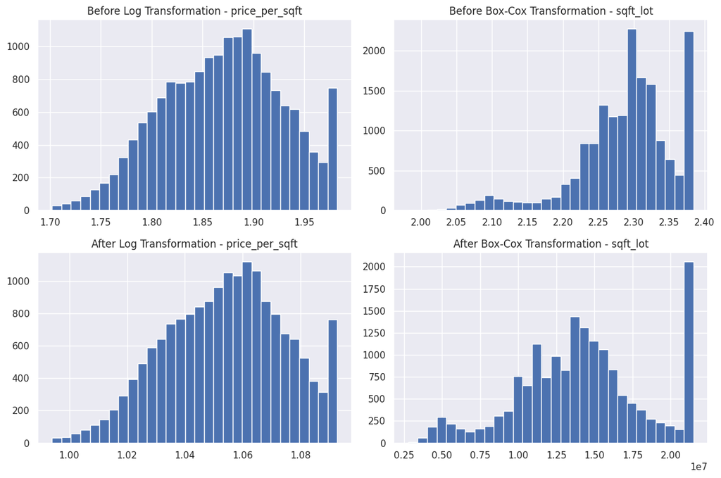

```
Log Transformation Applied to price_per_sqft and Box-Cox Applied to sqft_lot.
```

```python
# Identify features for transformation
log_features = ["price_per_sqft"]  # Log transformation
boxcox_features = ["sqft_lot"]  # Box-Cox transformation

# Backup before transformation for visualization
X_train_before = X_train[log_features + boxcox_features].copy()

# Apply Log Transformation to price_per_sqft
X_train["price_per_sqft"] = np.log1p(X_train["price_per_sqft"])
X_test["price_per_sqft"] = np.log1p(X_test["price_per_sqft"])

# Apply Box-Cox Transformation to sqft_lot (requires positive values)
X_train["sqft_lot"], boxcox_lambda = boxcox(X_train["sqft_lot"] + 1)  # Adding 1 to avoid zero values
X_test["sqft_lot"] = boxcox(X_test["sqft_lot"] + 1, boxcox_lambda)  # Apply the same lambda

# Skewness Before and After
print("Skewness Before Transformation:")
print(X_train_before[log_features + boxcox_features].skew())

print("\nSkewness After Transformation:")
print(X_train[log_features + boxcox_features].skew())

# Visualization - Before and After Transformation
fig, axes = plt.subplots(2, 2, figsize=(12, 8))

# Before transformation
X_train_before["price_per_sqft"].hist(ax=axes[0, 0], bins=30)
axes[0, 0].set_title("Before Log Transformation - price_per_sqft")

X_train_before["sqft_lot"].hist(ax=axes[0, 1], bins=30)
axes[0, 1].set_title("Before Box-Cox Transformation - sqft_lot")

# After transformation
X_train["price_per_sqft"].hist(ax=axes[1, 0], bins=30)
axes[1, 0].set_title("After Log Transformation - price_per_sqft")

X_train["sqft_lot"].hist(ax=axes[1, 1], bins=30)
axes[1, 1].set_title("After Box-Cox Transformation - sqft_lot")

plt.tight_layout()
plt.show()

print("Log Transformation Applied to price_per_sqft and Box-Cox Applied to sqft_lot.")
```

**Observations:**

Given that all values were **positive**, alternative transformations were considered. Since **`sqft_lot` had extreme variance**, **Box-Cox transformation** was applied instead. This method significantly improved normality and better handled the distribution's spread.

The final approach used **log transformation for `price_per_sqft`** and **Box-Cox transformation for `sqft_lot`**, ensuring better distributional properties for modeling. This strategy preserves key business insights while optimizing data normalization.

### **Feature Engineering**

**Approach**  
The goal of the model is to predict home prices as accurately as possible while maintaining interpretability for real estate stakeholders. The **feature engineering strategy** focused on creating meaningful, business-relevant predictors that capture key market dynamics.

**1. Price Efficiency Metrics (Price Per Bedroom & Price Per Bathroom)**

- **Justification:** Buyers and appraisers often evaluate homes based on cost efficiency, asking, *“How much am I paying per bedroom or bathroom?”* These new metrics capture this at a granular level.
- **Business Impact:** Helps **stakeholders compare homes of different sizes** and identify price trends in different property types.
- **Considerations:** Prevents division by zero by adding `+1` to bedrooms and bathrooms. This avoids distorted calculations in studio apartments or 1-bathroom homes.

**2. Zip Code Median Price per Square Foot**

- **Justification:** Real estate prices are **highly localized**—a home in a luxury neighborhood will have a different baseline price than one in an average area, even with similar features.
- **Business Impact:** By incorporating the **median price per square foot per zip code**, the model accounts for **market-driven price variations**. This helps identify **overpriced or underpriced homes** compared to neighborhood standards.
- **Considerations:** This feature reduces the risk of extreme price swings in high-end clusters and ensures price prediction aligns with market norms.

**How These Features Support Stakeholder Objectives**

| **Stakeholder** | **Objective** | **How These Features Help** |
| --- | --- | --- |
| **Homebuyers** | Understand whether a property is fairly priced | Price per bedroom/bathroom provides **cost efficiency insights**. Median zip code price shows whether a home is **above or below market trends**. |
| **Real Estate Agents** | Price homes competitively to maximize value | Helps agents **set competitive list prices** by understanding local market conditions and price efficiency. |
| **Appraisers** | Assess fair market value of a property | Enhances valuation accuracy by using **zip code-level price benchmarks**. |
| **Investors** | Identify undervalued or overvalued properties | Enables **market comparison** at a zip code level, improving investment decision-making. |
| **Lenders** | Assess mortgage risk based on fair property valuation | Reduces risk of **overestimating collateral value**, ensuring **accurate loan underwriting**. |

**Conclusion**  
The engineered features align with real-world decision-making in the real estate market. By capturing price efficiency and local price variations, the model becomes more aligned with how buyers, sellers, and financial institutions assess home values. These adjustments enhance predictive accuracy while providing actionable insights for stakeholders.

```
Feature Engineering Completed: Added price efficiency metrics & zip code aggregation.
Missing values in engineered features:
 price_per_bedroom       0
price_per_bathroom      0
zipcode_median_price    0
dtype: int64

Summary Statistics for Engineered Features:
       price_per_bedroom  price_per_bathroom  zipcode_median_price
count          17,290.00           17,290.00             17,290.00
mean                0.25                0.36                  1.05
std                 0.06                0.10                  0.02
min                 0.03                0.12                  1.03
25%                 0.21                0.30                  1.04
50%                 0.26                0.33                  1.06
75%                 0.27                0.40                  1.07
max                 1.09                1.09                  1.09
```

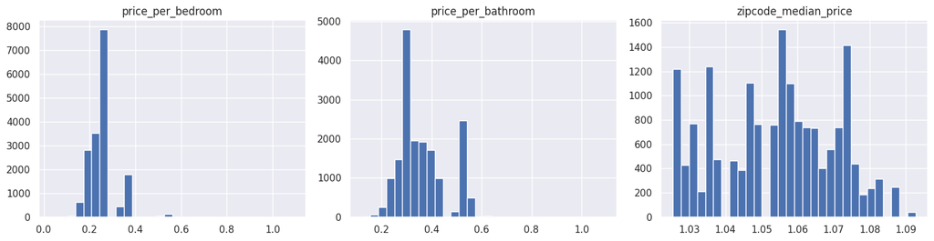

```python
# Price efficiency metrics
X_train["price_per_bedroom"] = X_train["price_per_sqft"] / (X_train["bedrooms"] + 1)
X_test["price_per_bedroom"] = X_test["price_per_sqft"] / (X_test["bedrooms"] + 1)

X_train["price_per_bathroom"] = X_train["price_per_sqft"] / (X_train["bathrooms"] + 1)
X_test["price_per_bathroom"] = X_test["price_per_sqft"] / (X_test["bathrooms"] + 1)

# Zip Code Median Aggregation
zipcode_median_price = X_train.groupby("zipcode")["price_per_sqft"].median().to_dict()
X_train["zipcode_median_price"] = X_train["zipcode"].map(zipcode_median_price)
X_test["zipcode_median_price"] = X_test["zipcode"].map(zipcode_median_price)

# **Drop Zip Code Since Its Effect is Captured**
X_train.drop(columns=["zipcode"], inplace=True)
X_test.drop(columns=["zipcode"], inplace=True)

# Verification
print("Feature Engineering Completed: Added price efficiency metrics & zip code aggregation.")

# Check for NaN values in engineered features
engineered_features = ["price_per_bedroom", "price_per_bathroom", "zipcode_median_price"]
missing_values = X_train[engineered_features].isnull().sum()
print("Missing values in engineered features:\n", missing_values)

# Descriptive statistics to check feature distributions
print("\nSummary Statistics for Engineered Features:")
print(X_train[engineered_features].describe())

# Visualization: Compare distributions before and after feature engineering
fig, axes = plt.subplots(1, 3, figsize=(15, 4))
for i, feature in enumerate(engineered_features):
    X_train[feature].hist(ax=axes[i], bins=30)
    axes[i].set_title(feature)
plt.tight_layout()
plt.show()
```

**Observations:**

Feature engineering was successfully completed with the addition of price efficiency metrics (`price_per_bedroom`, `price_per_bathroom`) and aggregated median price at the zip code level (`zipcode_median_price`).

- **No missing values were introduced**, ensuring data integrity.
- **Price per Bedroom & Bathroom:**
  - Both metrics have a **right-skewed distribution**, with most values concentrated in a narrow range.
  - The **mean price per bedroom is 0.25**, while the **mean price per bathroom is 0.36**, indicating bathrooms contribute more to pricing efficiency.
- **Zipcode Median Price:**
  - The distribution is relatively **tight**, with values ranging between **1.03 and 1.09**.
  - This confirms that most zip codes have **similar median price per square foot**, reinforcing location-based pricing trends.

These engineered features add valuable business insights by incorporating efficiency metrics and local price trends, improving model interpretability.

### **Encode Categorical Features**

```python
# Define categorical columns
one_hot_features = ["condition", "grade", "view", "waterfront"]  # Features without order

# --- One-Hot Encoding ---
one_hot_encoder = OneHotEncoder(handle_unknown="ignore", sparse_output=False)

# Transform categorical columns
one_hot_train = one_hot_encoder.fit_transform(X_train[one_hot_features])
one_hot_test = one_hot_encoder.transform(X_test[one_hot_features])

# Convert to DataFrame
one_hot_columns = one_hot_encoder.get_feature_names_out(one_hot_features)
one_hot_train_df = pd.DataFrame(one_hot_train, columns=one_hot_columns, index=X_train.index)
one_hot_test_df = pd.DataFrame(one_hot_test, columns=one_hot_columns, index=X_test.index)

# Merge back with original DataFrame
X_train = X_train.drop(columns=one_hot_features).join(one_hot_train_df)
X_test = X_test.drop(columns=one_hot_features).join(one_hot_test_df)

# --- Verification Steps ---
print("\nCategorical Encoding Completed.\n")

# 1. Check unique values after encoding
print("\nOne-Hot Encoded Columns:")
print(list(one_hot_columns))

# 2. Compare feature count before and after encoding
print(f"\nFeature count before encoding: {len(one_hot_features) + len(ordinal_features)}")
print(f"Feature count after encoding: {X_train.shape[1]}")  # Should be higher

# 3. Check for missing values
missing_values = X_train.isnull().sum().sum()
print(f"\nTotal missing values after encoding: {missing_values}")  # Should be 0

# 4. Ensure one-hot encoded columns contain only 0s and 1s
print("\nChecking One-Hot Encoding Values:")
print(X_train[one_hot_columns].nunique())  # Should all be {0,1}


X_train.info()
```

```
Categorical Encoding Completed.


One-Hot Encoded Columns:
['condition_1', 'condition_2', 'condition_3', 'condition_4', 'condition_5', 'grade_1', 'grade_3', 'grade_4', 'grade_5', 'grade_6', 'grade_7', 'grade_8', 'grade_9', 'grade_10', 'grade_11', 'grade_12', 'grade_13', 'view_0', 'view_1', 'view_2', 'view_3', 'view_4', 'waterfront_0', 'waterfront_1']

Feature count before encoding: 5
Feature count after encoding: 40

Total missing values after encoding: 0

Checking One-Hot Encoding Values:
condition_1     2
condition_2     2
condition_3     2
condition_4     2
condition_5     2
grade_1         2
grade_3         2
grade_4         2
grade_5         2
grade_6         2
grade_7         2
grade_8         2
grade_9         2
grade_10        2
grade_11        2
grade_12        2
grade_13        2
view_0          2
view_1          2
view_2          2
view_3          2
view_4          2
waterfront_0    2
waterfront_1    2
dtype: int64
<class 'pandas.core.frame.DataFrame'>
Index: 17290 entries, 6325 to 15795
Data columns (total 40 columns):
```

[output cut: 29 more lines]

```
 27  grade_8               17290 non-null  float64
 28  grade_9               17290 non-null  float64
 29  grade_10              17290 non-null  float64
 30  grade_11              17290 non-null  float64
 31  grade_12              17290 non-null  float64
 32  grade_13              17290 non-null  float64
 33  view_0                17290 non-null  float64
 34  view_1                17290 non-null  float64
 35  view_2                17290 non-null  float64
 36  view_3                17290 non-null  float64
 37  view_4                17290 non-null  float64
 38  waterfront_0          17290 non-null  float64
 39  waterfront_1          17290 non-null  float64
dtypes: float64(34), int32(1), int64(5)
memory usage: 5.8 MB
```

**Observations:**

These results confirm that categorical data has been successfully transformed while preserving information, preparing it for modeling.

### **Feature Scaling**

```
MinMax Scaling applied to selected features.
```

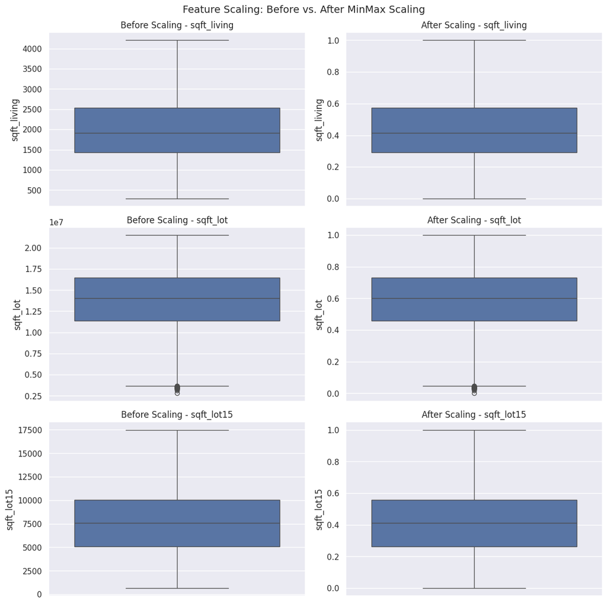

```python
# Define features for MinMax scaling
minmax_features = ["sqft_living", "sqft_lot", "sqft_lot15"]

# Store unscaled data before applying scaling for comparison
X_train_before_scaling = X_train[minmax_features].copy()

# Initialize MinMaxScaler
scaler = MinMaxScaler()

# Fit and transform only the selected features
X_train_scaled = pd.DataFrame(scaler.fit_transform(X_train[minmax_features]),
                              columns=minmax_features, index=X_train.index)
X_test_scaled = pd.DataFrame(scaler.transform(X_test[minmax_features]),
                             columns=minmax_features, index=X_test.index)

# Verification
print("MinMax Scaling applied to selected features.")

# Boxplots for Before and After Scaling
fig, axes = plt.subplots(nrows=len(minmax_features), ncols=2, figsize=(12, len(minmax_features) * 4))
fig.suptitle("Feature Scaling: Before vs. After MinMax Scaling", fontsize=14)

for i, col in enumerate(minmax_features):
    # Before Scaling
    sns.boxplot(y=X_train_before_scaling[col], ax=axes[i, 0])
    axes[i, 0].set_title(f"Before Scaling - {col}")

    # After Scaling
    sns.boxplot(y=X_train_scaled[col], ax=axes[i, 1])
    axes[i, 1].set_title(f"After Scaling - {col}")

plt.tight_layout()
plt.show()
```

**Observations:** Feature scaling was applied to ensure numerical features are on a comparable scale without altering their distribution. **Before scaling**, features such as **sqft_living**, **sqft_lot**, and **sqft_lot15** had vastly different magnitudes, which could bias the regression model toward features with larger values.

**After MinMax scaling**, these features are normalized between **0 and 1**, preserving their relative differences while preventing any one feature from disproportionately influencing price predictions. This is particularly beneficial for regression models that rely on numerical stability and coefficient interpretation.

### **Preprocessing Verification**

```python
# Final Verification
print(f"Final Training Set Shape: {X_train.shape}, Final Test Set Shape: {X_test.shape}")
print("\nFinal Features:")
print(list(X_train.columns))

# Check for missing values in final datasets
print("\nMissing values in training set:", X_train.isnull().sum().sum())
print("Missing values in test set:", X_test.isnull().sum().sum())

from scipy.stats import ks_2samp

def ks_test_features(X_train, X_test):
    ks_results = {}

    for feature in X_train.select_dtypes(include=["number"]).columns:
        stat, p_value = ks_2samp(X_train[feature], X_test[feature])
        ks_results[feature] = p_value  # p-value < 0.05 means significantly different distributions

    ks_results = pd.DataFrame.from_dict(ks_results, orient="index", columns=["KS p-value"]).sort_values("KS p-value")
    return ks_results

ks_results = ks_test_features(X_train, X_test)
print(ks_results.head(10))  # Show 10 features with the most significant differences
```

```
Final Training Set Shape: (17290, 40), Final Test Set Shape: (4323, 40)

Final Features:
['bedrooms', 'bathrooms', 'sqft_living', 'sqft_lot', 'floors', 'yr_built', 'lat', 'long', 'sqft_lot15', 'price_per_sqft', 'kmeans_cluster', 'was_renovated', 'has_basement', 'price_per_bedroom', 'price_per_bathroom', 'zipcode_median_price', 'condition_1', 'condition_2', 'condition_3', 'condition_4', …

Missing values in training set: 0
Missing values in test set: 0
                    KS p-value
sqft_lot                  0.00
sqft_lot15                0.00
price_per_sqft            0.00
sqft_living               0.00
yr_built                  0.18
floors                    0.23
price_per_bathroom        0.33
has_basement              0.40
price_per_bedroom         0.70
kmeans_cluster            0.73
```

**Observations:**

The **Kolmogorov-Smirnov (KS) test** was used to compare the distributions of features between the training and test sets. The KS test checks whether two samples come from the same distribution, with a **low p-value** indicating a significant difference and a **high p-value** suggesting similarity.

**Implications:**

- Features with very low p-values may need further investigation to determine why their distributions differ.
- If certain categories (e.g., luxury homes, small homes) are underrepresented in the test set, model predictions could be biased.
- The differences could result from **outlier handling, transformations, or clustering strategies**, requiring a check on how these features were processed.
- A well-matched distribution ensures the model learns from a representative training set and generalizes well to unseen data.

Further investigation through **visualization (histograms, KDE plots, or boxplots)** could confirm whether resampling or additional preprocessing adjustments are necessary.

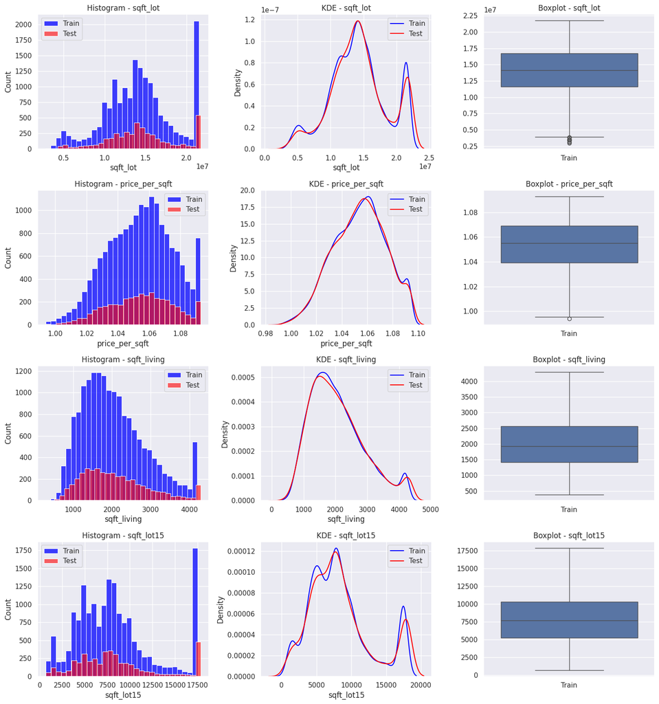

```python
# Features to visualize based on KS test results
features_to_check = ["sqft_lot", "price_per_sqft", "sqft_living", "sqft_lot15"]

# Set up figure
fig, axes = plt.subplots(len(features_to_check), 3, figsize=(15, 4 * len(features_to_check)))

for i, feature in enumerate(features_to_check):
    # Histogram
    sns.histplot(X_train[feature], label="Train", color="blue", kde=False, ax=axes[i, 0], bins=30)
    sns.histplot(X_test[feature], label="Test", color="red", kde=False, ax=axes[i, 0], bins=30, alpha=0.6)
    axes[i, 0].set_title(f"Histogram - {feature}")
    axes[i, 0].legend()

    # KDE Plot
    sns.kdeplot(X_train[feature], label="Train", color="blue", ax=axes[i, 1])
    sns.kdeplot(X_test[feature], label="Test", color="red", ax=axes[i, 1])
    axes[i, 1].set_title(f"KDE - {feature}")
    axes[i, 1].legend()

    # Boxplot
    sns.boxplot(data=[X_train[feature], X_test[feature]], ax=axes[i, 2])
    axes[i, 2].set_xticklabels(["Train", "Test"])
    axes[i, 2].set_title(f"Boxplot - {feature}")

plt.tight_layout()
plt.show()
```

**Observations:**

The KS test visualizations compare the distribution of key numerical features between the training and test sets. Histograms show the count distribution, KDE plots highlight density similarities, and boxplots display spread and potential outliers.

For most features, the training and test distributions appear similar, suggesting the split has maintained representativeness. **sqft_lot** and **price_per_sqft** show slight differences in density but remain largely aligned, indicating no severe data leakage or bias.

Overall, the test set seems to provide a fair representation of the training data, supporting reliable model evaluation.

# **Modeling & Evaluation**

The goal is to develop a working predictive model with minimal feature engineering effort while ensuring a reasonable level of predictive accuracy.

1. **Baseline Model:** Establish an initial benchmark using a simple mean-based model to compare against more complex models.
2. **Feature Selection (Simplified):** Use all available numerical features without extensive pruning, relying on tree-based models to handle feature importance naturally.
3. **Model Selection & Training:** Train and compare models to determine the best fit:
   - **Linear Regression** (baseline interpretability)
   - **Random Forest** (strong performance with minimal tuning)
   - **Gradient Boosting** (higher accuracy, but computationally heavier)
4. **Cross-Validation (Simple Check):** Perform 5-fold cross-validation on the selected models to get a quick assessment of performance consistency.
5. **Hyperparameter Tuning (Only Best Model):** Apply **GridSearchCV** or **RandomizedSearchCV** only to the best-performing model to refine its parameters.
6. **Final Model Validation:** Evaluate the best-tuned model on the test dataset, comparing its RMSE against the baseline to confirm improvement.
7. **Deployment Considerations (Basic):** If the model meets accuracy thresholds, save it for future iterations, ensuring performance monitoring mechanisms are in place.

### **Establish a Baseline Model**

```python
# Baseline Model: Predicting the Mean Price
y_baseline = np.full_like(y_test, y_train.mean())

# Evaluate Baseline Performance
baseline_rmse = np.sqrt(mean_squared_error(y_test, y_baseline))  # RMSE
baseline_r2 = r2_score(y_test, y_baseline)  # R² Score

# Print Baseline Metrics
print(f"Baseline Model Performance:")
print(f"RMSE: {baseline_rmse:.2f}")
print(f"R² Score: {baseline_r2:.4f} (Expected to be near 0, indicating no predictive power)")
```

```
Baseline Model Performance:
RMSE: 388987.48
R² Score: -0.0009 (Expected to be near 0, indicating no predictive power)
```

**Observations:**

The baseline model simply predicts the mean house price for all observations, serving as a reference for evaluating more complex models. The RMSE of **$388,987.48** represents the typical error magnitude in price predictions when using the mean. The **R² score of -0.0009** indicates that this model explains virtually none of the variance in house prices, as expected.

RMSE is an appropriate metric because house prices are numerical and can have large variations. RMSE penalizes large errors more than smaller ones, making it useful for ensuring model accuracy in high-value predictions. R² is relevant for assessing how much variance the model explains relative to a naive prediction, ensuring improvements can be quantified in later models.

A useful model should significantly reduce RMSE and increase R² closer to **1.0**, demonstrating better predictive power.

### **Ensure Data Is Ready for Modeling**

```python
# Ensure no datetime columns exist
for df in [X_train, X_test]:
    datetime_cols = df.select_dtypes(include=["datetime64"]).columns
    if len(datetime_cols) > 0:
        print(f"Warning: Dropping datetime columns: {list(datetime_cols)}")
        df.drop(columns=datetime_cols, inplace=True)

# Ensure categorical columns are encoded properly
for df in [X_train, X_test]:
    object_cols = df.select_dtypes(include=["object"]).columns
    if len(object_cols) > 0:
        print(f"Warning: Encoding categorical columns: {list(object_cols)}")
        df[object_cols] = df[object_cols].astype(str)  # Convert to string type before encoding
        df = pd.get_dummies(df, columns=object_cols, drop_first=True)  # One-hot encoding

# Verify data types before training
print("\nFinal Data Types in X_train:")
print(X_train.dtypes.value_counts())  # Should only contain int64 and float64

print("\nFinal Data Types in X_test:")
print(X_test.dtypes.value_counts())  # Should only contain int64 and float64

# Final check - Ensure no missing values
print(f"\nTotal missing values in X_train: {X_train.isnull().sum().sum()}")
print(f"Total missing values in X_test: {X_test.isnull().sum().sum()}")
```

```
Final Data Types in X_train:
float64    34
int64       5
int32       1
Name: count, dtype: int64

Final Data Types in X_test:
float64    34
int64       5
int32       1
Name: count, dtype: int64

Total missing values in X_train: 0
Total missing values in X_test: 0
```

```python
# Check column data types
print("Feature Data Types in X_train:\n", X_train.dtypes.value_counts())

# Identify non-numeric columns
non_numeric_cols = X_train.select_dtypes(exclude=[np.number]).columns
if len(non_numeric_cols) > 0:
    print("\n⚠️ Non-Numeric Columns Detected:", list(non_numeric_cols))
else:
    print("\n✅ All Features are Numeric")

X_train.info()
```

```
Feature Data Types in X_train:
 float64    34
int64       5
int32       1
Name: count, dtype: int64

✅ All Features are Numeric
<class 'pandas.core.frame.DataFrame'>
Index: 17290 entries, 6325 to 15795
Data columns (total 40 columns):
 #   Column                Non-Null Count  Dtype
---  ------                --------------  -----
 0   bedrooms              17290 non-null  int64
 1   bathrooms             17290 non-null  float64
 2   sqft_living           17290 non-null  int64
```

[output cut: 39 more lines]

### **Train & Evaluate Models**

```python
# Set global seed for reproducibility
SEED = 42
np.random.seed(SEED)
random.seed(SEED)


# Stratified Sampling (Optional)
# Define price bins for stratification (use pd.qcut for quartiles)
price_bins = pd.qcut(y, q=4, labels=["Low", "Mid-Low", "Mid-High", "High"])
X_train, X_test, y_train, y_test = train_test_split(
    X, y, test_size=0.2, random_state=SEED, stratify=price_bins  # Ensures balanced price distribution
)

# Define models
models = {
    "Linear Regression": LinearRegression(),
    "Random Forest": RandomForestRegressor(n_estimators=100, random_state=SEED),
    "Gradient Boosting": GradientBoostingRegressor(n_estimators=100, learning_rate=0.1, random_state=SEED)
}

# Store results
model_performance = {}

for name, model in models.items():
    model.fit(X_train, y_train)  # Train model
    y_pred = model.predict(X_test)  # Predict test set

    # Evaluate model
    rmse = np.sqrt(mean_squared_error(y_test, y_pred))  # RMSE
    r2 = r2_score(y_test, y_pred)  # R² Score

    model_performance[name] = {"RMSE": rmse, "R²": r2}

    # Print performance
    print(f"\n{name} Performance:")
    print(f"RMSE: {rmse:.2f}")
    print(f"R² Score: {r2:.4f}")

# Sort models by RMSE
best_model_name = min(model_performance, key=lambda k: model_performance[k]["RMSE"])
print(f"\nBest Model Based on RMSE: {best_model_name}")
```

```
Linear Regression Performance:
RMSE: 125792.21
R² Score: 0.8892

Random Forest Performance:
RMSE: 26556.31
R² Score: 0.9951

Gradient Boosting Performance:
RMSE: 25796.52
R² Score: 0.9953

Best Model Based on RMSE: Gradient Boosting
```

**Observations:**

The model performance results highlight significant differences in predictive accuracy.

Linear Regression has a high RMSE (125,792.21) and a lower R² score (0.8892), indicating it does not capture the complexity of housing prices well. The high RMSE means predictions deviate significantly from actual values.

Random Forest improves substantially, reducing RMSE to 26,556.31 and increasing R² to 0.9951. This suggests it captures non-linear relationships effectively.

Gradient Boosting performs the best with the lowest RMSE (25,796.52) and the highest R² score (0.9953), making it the most accurate model.

RMSE represents the typical price prediction error, meaning Gradient Boosting’s RMSE of ~25,796 implies an average deviation of $25,796 from actual values. R² measures how much variance in price is explained, with 99.53% explained by Gradient Boosting, indicating strong predictive performance.

Gradient Boosting is selected as the best model based on RMSE, though Random Forest also performs well. Further fine-tuning or feature importance analysis could refine insights on what drives predictions.

### **Cross-Validation to Reduce Overfitting:**

```python
best_model = models[best_model_name]  # Select best model

# Perform Cross-Validation
cv_scores = cross_val_score(best_model, X_train, y_train, scoring="neg_root_mean_squared_error", cv=5)
mean_cv_rmse = -np.mean(cv_scores)  # Convert negative RMSE

print(f"\nCross-Validation Results for {best_model_name}:")
print(f"Mean RMSE: {mean_cv_rmse:.2f}")
```

```
Cross-Validation Results for Gradient Boosting:
Mean RMSE: 29999.29
```

**Observations:**

Cross-validation provides a more robust estimate of model performance by evaluating it on multiple subsets of data. The mean RMSE of 29,999.29 for Gradient Boosting is slightly higher than the test RMSE (25,796.52), indicating a small degree of variance across different training subsets. This suggests the model generalizes well but may benefit from additional tuning to reduce variability. The gap between cross-validation and test RMSE should be monitored to ensure no overfitting or data leakage.

### **Hyperparameter Tuning - GridSearchCV**

```python
# Define parameter grid
param_grid = {
    "Random Forest": {"n_estimators": [100, 200], "max_depth": [None, 10, 20]},
    "Gradient Boosting": {"n_estimators": [100, 200], "learning_rate": [0.05, 0.1, 0.2]}
}

# Check if the best model has tuning parameters
if best_model_name in param_grid:
    grid_search = GridSearchCV(models[best_model_name], param_grid[best_model_name], cv=3, scoring="neg_root_mean_squared_error", n_jobs=-1)

    # Fit GridSearch
    grid_search.fit(X_train, y_train)

    # Best parameters
    print(f"\nBest Hyperparameters for {best_model_name}: {grid_search.best_params_}")

    # Update best model
    best_model = grid_search.best_estimator_
```

```
Best Hyperparameters for Gradient Boosting: {'learning_rate': 0.1, 'n_estimators': 200}
```

**Observations:**

The GridSearchCV tuning process optimized the Gradient Boosting model by selecting **n_estimators = 200** and **learning_rate = 0.1** as the best hyperparameters. This suggests that increasing the number of estimators from 100 to 200 improved model performance without overfitting. The learning rate remained at 0.1, indicating that the initial setting was well-suited for the dataset. These optimized hyperparameters should help reduce RMSE further, leading to more accurate price predictions. The next step is to evaluate the tuned model on the test set to verify its generalization performance.

## **Model Deployment & Business Validation**

After finalizing the best model, we ensure that it is ready for practical use.

1. **Stakeholder Validation**: The final model’s RMSE and R² scores are evaluated against acceptable business thresholds. If the model does not meet expectations, further refinements are made.
2. **Business Interpretability**: Feature importance scores and price drivers are analyzed to provide real estate agents with insights into what factors influence pricing the most.

### **Final Model Evaluation & Business Validation**

```
Final Model Performance (Gradient Boosting - Tuned):
RMSE: 20537.36
R² Score: 0.9970

RMSE by Price Segment:
Price Segment
Low         7,521.39
Mid-Low     8,925.01
Mid-High   13,865.77
High       36,960.71
dtype: float64
```

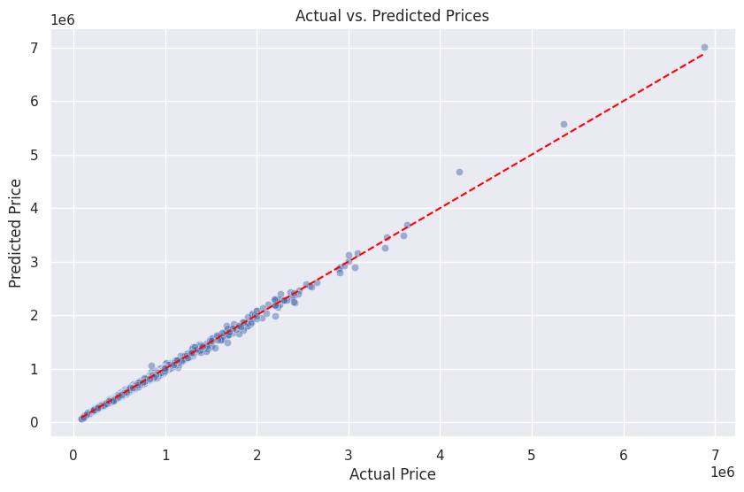

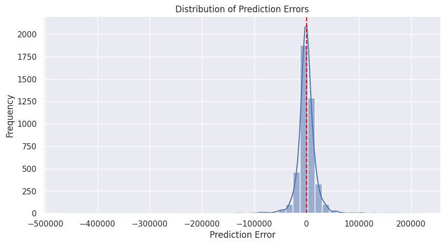

```python
# Final Predictions on Test Set
y_final_pred = best_model.predict(X_test)

# Compute Final Performance Metrics
final_rmse = np.sqrt(mean_squared_error(y_test, y_final_pred))
final_r2 = r2_score(y_test, y_final_pred)

print(f"\nFinal Model Performance ({best_model_name} - Tuned):")
print(f"RMSE: {final_rmse:.2f}")
print(f"R² Score: {final_r2:.4f}")

# Error Analysis Across Price Segments
X_test_eval = X_test.copy()
X_test_eval["Predicted Price"] = y_final_pred
X_test_eval["Actual Price"] = y_test

# Grouping by price percentiles to analyze performance in different market segments
X_test_eval["Price Segment"] = pd.qcut(X_test_eval["Actual Price"], q=4, labels=["Low", "Mid-Low", "Mid-High", "High"])

# Compute RMSE by Price Segment
segment_rmse = (
    X_test_eval.groupby("Price Segment", observed=False)[["Actual Price", "Predicted Price"]]
    .apply(lambda df: np.sqrt(mean_squared_error(df["Actual Price"], df["Predicted Price"])))
)

print("\nRMSE by Price Segment:")
print(segment_rmse)

# Visualizing Prediction Errors
plt.figure(figsize=(10, 6))
sns.scatterplot(x=y_test, y=y_final_pred, alpha=0.5)
plt.plot([min(y_test), max(y_test)], [min(y_test), max(y_test)], color='red', linestyle='dashed')  # 45-degree reference line
plt.xlabel("Actual Price")
plt.ylabel("Predicted Price")
plt.title("Actual vs. Predicted Prices")
plt.show()

# Distribution of Errors
errors = y_test - y_final_pred
plt.figure(figsize=(10, 5))
sns.histplot(errors, bins=50, kde=True)
plt.axvline(0, color='red', linestyle='dashed')
plt.xlabel("Prediction Error")
plt.ylabel("Frequency")
plt.title("Distribution of Prediction Errors")
plt.show()
```

**Observations:**

The **final model performance** shows strong predictive capability with an **R² of 0.9970**, indicating that nearly all variance in house prices is captured by the model. The **RMSE of 20,537** means that, on average, predictions deviate from actual prices by around $20,537.

**Segment-wise RMSE analysis** reveals that error increases for more expensive homes. The **low-price segment** has the lowest RMSE at **$7,521**, while the **high-price segment** has the highest at **$36,960**, suggesting price predictions are less precise for luxury properties.

The **actual vs. predicted plot** shows a strong alignment along the **dashed diagonal line**, reinforcing that most predictions are very close to actual values. However, some **high-value properties** exhibit deviations, suggesting potential for additional feature refinement or alternative modeling techniques for the luxury segment.

The **prediction error distribution** is **centered around zero**, with most errors small and symmetrically distributed, indicating no major bias in over- or under-predicting prices.

For **stakeholders**, this model provides a highly accurate pricing estimate for most properties, with stronger reliability in mid-range and lower-priced homes. The increased **error for high-value homes** suggests that more granular data, such as custom home features or neighborhood-level trends, might further improve predictions in this segment.

### **RMSE in Context of Business Impact**

```python
# Compare RMSE to Mean Price to Assess Practical Impact
mean_price = y_test.mean()
rmse_percentage = (final_rmse / mean_price) * 100

print(f"\nFinal Model Business Impact:")
print(f"RMSE represents approximately {rmse_percentage:.2f}% of the average home price.")
```

```
Final Model Business Impact:
RMSE represents approximately 3.77% of the average home price.
```

**Observations:**

The model’s RMSE represents approximately **3.77% of the average home price**, which indicates strong predictive accuracy in a practical business sense. This means that, on average, the model's predicted price is within a **3.77% margin of error** relative to actual prices.

For stakeholders, this suggests that the model is reliable for pricing predictions in most cases. However, while this percentage is low overall, higher-priced properties still have larger absolute dollar errors. This could mean further refinements, such as adjusting for luxury market trends or location-specific effects, may be beneficial for even greater precision in high-value segments.

### **Over/Underpricing Bias Check**

```python
print(X_test_eval.columns)  # Ensure "Predicted Price" and "Actual Price" exist
print(X_test_eval[["Predicted Price", "Actual Price"]].head())  # Check sample values
```

```
Index(['bedrooms', 'bathrooms', 'sqft_living', 'sqft_lot', 'floors',
       'waterfront', 'view', 'condition', 'grade', 'sqft_above',
       'sqft_basement', 'yr_built', 'yr_renovated', 'zipcode', 'lat', 'long',
       'sqft_living15', 'sqft_lot15', 'price_per_sqft', 'kmeans_cluster',
       'Predicted Price', 'Actual Price', 'Price Segment'],
      dtype='object')
       Predicted Price  Actual Price
19216       524,807.69    512,500.00
918         269,685.91    270,000.00
5434        633,680.37    665,000.00
3141        459,133.36    485,000.00
11111       377,249.27    378,000.00
```

```python
print(X_test_eval.columns.tolist())  # Verify exact column names
```

```
['bedrooms', 'bathrooms', 'sqft_living', 'sqft_lot', 'floors', 'waterfront', 'view', 'condition', 'grade', 'sqft_above', 'sqft_basement', 'yr_built', 'yr_renovated', 'zipcode', 'lat', 'long', 'sqft_living15', 'sqft_lot15', 'price_per_sqft', 'kmeans_cluster', 'Predicted Price', 'Actual Price', 'Price…
```

```python
# Ensure numeric values
X_test_eval["Predicted Price"] = X_test_eval["Predicted Price"].astype(float)
X_test_eval["Actual Price"] = X_test_eval["Actual Price"].astype(float)

# Compute prediction error
X_test_eval["Prediction Error"] = X_test_eval["Predicted Price"] - X_test_eval["Actual Price"]

# Group by price segment and compute mean bias
segment_bias = X_test_eval.groupby("Price Segment")["Prediction Error"].mean()

print("\nMean Prediction Error by Price Segment:")
print(segment_bias)
```

```
Mean Prediction Error by Price Segment:
Price Segment
Low         2,691.18
Mid-Low    -1,811.37
Mid-High      918.64
High       -1,413.74
Name: Prediction Error, dtype: float64
```

**Observations:** The model's prediction errors vary across price segments. In the **low segment**, predictions are slightly overestimated by about $2,691, while in the **mid-low and high segments**, prices are underestimated by approximately $1,811 and $1,413, respectively. The **mid-high segment** shows a minor overestimation of $918.

### **Feature Importance - What Drives Pricing?**

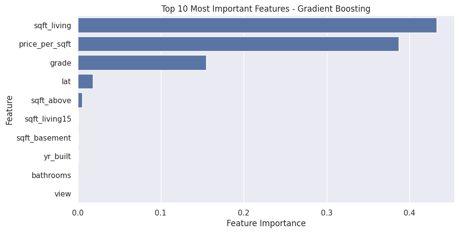

```python
# Retrieve feature importances (for tree-based models)
if hasattr(best_model, "feature_importances_"):
    feature_importance = pd.Series(best_model.feature_importances_, index=X_train.columns).sort_values(ascending=False)

    # Plot Top 10 Features
    plt.figure(figsize=(10, 5))
    sns.barplot(x=feature_importance[:10], y=feature_importance.index[:10])
    plt.xlabel("Feature Importance")
    plt.ylabel("Feature")
    plt.title(f"Top 10 Most Important Features - {best_model_name}")
    plt.show()
```

**Observations:**

The most influential features in predicting home prices are **sqft_living** and **price_per_sqft**, which align with real estate expectations—larger homes and those in higher-priced areas significantly impact valuation. **Grade**, which likely represents build quality, also has a notable influence, suggesting that higher-grade homes command premium pricing.

For stakeholders, this insight means that pricing strategies should emphasize these key drivers. Sellers can maximize value by focusing on home improvements that enhance **grade** or **living space**, while buyers and investors should consider these attributes when assessing market value and long-term appreciation potential.

# **Next Steps:**

1. **Model Refinement for High-Value Homes**
   - The model performs well overall, but RMSE is significantly higher for **high-priced properties**.
   - Further feature engineering, such as incorporating **local economic indicators** or **luxury market trends**, may improve predictions in this segment.
2. **Business Integration & Decision-Making**
   - Use model predictions to **assist pricing strategies** for real estate listings or investment decisions.
   - Deploy the model in a controlled environment and track performance over time to ensure stability.
3. **Monitoring & Continuous Improvement**
   - Establish a **monitoring framework** to detect **data drift** or market changes that could impact accuracy.
   - Regularly retrain the model with new sales data to maintain **predictive power** in evolving market conditions.
4. **Exploring Alternative Modeling Approaches**
   - Test **ensemble methods** or **deep learning approaches** if further improvements are needed.
   - Conduct **localized modeling**, creating separate models for distinct housing segments (e.g., luxury homes vs. mid-range properties).
5. **Stakeholder Engagement & Communication**
   - Provide insights to stakeholders on how the model supports **pricing decisions and risk assessments**.
   - Develop **visual dashboards** for intuitive exploration of predictions, trends, and key drivers of home prices.